# Modelação Bayesiana

Diogo Freitas

João Francisco Botas

Miguel Gonçalves

Ricardo Galvão

21-05-2025

# Modelação Bayesiana

Este projeto foi desenvolvido no âmbito da unidade curricular de Modelação Bayesiana do Mestrado em Ciência de Dados no Iscte. O objetivo do trabalho tem como objetivo replicar um artigo científico do ponto de vista Bayesiana e discutir os resultados obtidos. Para além disso, vamos beneficiar das vantagens que a modelação Bayesiana nos traz, como por exemplo a possibilidade de fazer inferência causal e a utilização de priors informativas.

## Índice

- Artigo de referência
- Fase 1 - EDA
  - Variáveis categóricas
  - Variáveis numéricas citadas no artigo
    - Correlação entre variáveis
    - Ver loadings e alpha de Cronbach
  - Análise das variáveis
    - Construtos criados no artigo
    - Variáveis não citadas no artigo
    - Variáveis descritivas
    - Criar próprios CFA como fazem no artigo (erradamente)
  - Criar ficheiros CSV na pasta data com os 4 conjuntos anteriores
- Fase 2 - Replicação do artigo
  - 1 - CFA para cada conjunto de questões
    - CFA com todas as variáveis
    - CFA com variáveis sugeridas pelo artigo
    - CFA com variáveis a escolher
  - 2 - CFA Global
    - Com as variáveis que os autores escolheram
    - Com as variáveis que escolhemos
  - 3 - SEM
    - Estimação com construtos dos autores (dataset original)
    - Construtos criados por nós
      - Média variáveis
      - CFA
    - Estimação com FA criadas no próprio modelo
    - Tentativa de melhoria com o SEM seguido
    - Comparação entre os dois SEM
  - 4 - SEM com priors
    - Priors para lambda, beta e ET12 e ET13
    - Priors com regressão 0

## Artigo de referência

O artigo de referência para este trabalho é o [Data on higher education student ethics model](https://www.sciencedirect.com/science/article/pii/S2352340919312594?via%3Dihub). Este artigo analisa dados de um questionário aplicado a estudantes de ensino superior para avaliar a ética dos mesmos. O questionário foi aplicado a 566 estudantes entre o período de Janeiro a Dezembro de 2018, na cidade de Yogyakarta, na Indonesia. Para percebermos melhor o conjunto de dados e a sua estrutura, vamos carregar o ficheiro de dados e fazer uma pequena analise exploratória de dados, complementando a informação com a descrição do artigo.

```r
# Escolher que modelos executar (sobretudo para a geração do ficheiro knited)

correr_single_CFAs_all <- FALSE
correr_single_CFAs_article <- FALSE
correr_single_CFAs_purpose <- correr_single_CFAs_article
correr_multiple_CFA <- FALSE
correr_SEM <- FALSE # TRUE
correr_SEM_cpriors <- FALSE # TRUE
```

## Fase 1 - EDA

```r
# load data
df <- read.csv("../data/dados_raw.csv")
# View(df)
# df %>% glimpse()
```

Skim do dataset para vermos a estrutura detalhada dos dados.

```r
df %>% skimr::skim() -> skim_output
###########
# skim_output
# str(skim_output) # ver a estrutura para filtrar
###########
min(skim_output$complete_rate) # todas as colunas têm valores preenchidos
max(colSums(is.na(df)))
```

```
## [1] 1
## [1] 0
```

Ao guardarmos o skim num objeto podemos ver a estrutura e filtrar as informações que queremos. Neste caso, conseguimos ver que todas as colunas: - têm todos os valores preenchidos $\rightarrow$ mínimo do `complete_rate` é 1; - não existem valores em falta, consequentemente $\rightarrow$ máximo do número de valores em falta é 0.

Ou seja, não teremos de lidar com omissos.

```r
# select character columns
skim_output$skim_variable[skim_output$skim_type == "character"] -> char_cols
char_cols
# select numeric columns
skim_output$skim_variable[skim_output$skim_type == "numeric"] -> num_cols
length(num_cols) # = 127 total - 1 (Fak)
```

```
## [1] "Fak"
## [1] 126
```

### Variáveis categóricas

No dataset só temos uma variável categórica, a `Fak`. Vamos fazer uma tabela de frequências para esta variável e um gráfico de barras. Esta variável, segundo o artigo, é a *faculty*/departamento a que o estudante pertence (**Table 8** artigo).

| Departamento | Nº alunos | Percentagem |
| --- | --- | --- |
| Economic | 114 | 20.1% |
| Engineering | 98 | 17.3% |
| Mathematics and Natural Science | 85 | 15.0% |
| Social Science | 61 | 10.8% |
| Sports Science | 15 | 2.7% |
| Art | 120 | 21.2% |
| Educational Science | 73 | 12.9% |

```r
# fazer uma tabela de frequências para as variáveis categóricas
df %>% dplyr::select(all_of(char_cols)) %>% map(table)
```

```
## $Fak
##
##  FBS   FE  FIK  FIP  FIS   FT MIPA
##  120  114   15   73   61   98   85
```

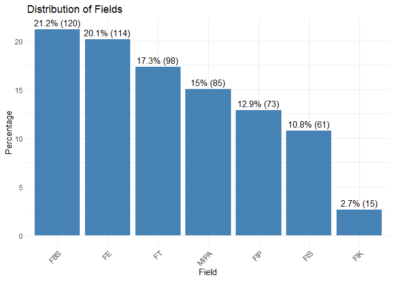

```r
# gráfico de barras
df %>%
  group_by(Fak) %>%
  summarise(Count = n()) %>%
  mutate(Percentage = Count / sum(Count) * 100) %>%
  ggplot(aes(x = reorder(Fak, -Percentage), y = Percentage)) +
  geom_bar(stat = "identity", fill = "steelblue") +
  geom_text(aes(label = paste0(round(Percentage, 1), "% (", Count, ")")), vjust = -0.5) +
  labs(x = "Field", y = "Percentage", title = "Distribution of Fields") +
  theme_minimal() +
  theme(axis.text.x = element_text(angle = 45, hjust = 1))
```

Conseguimos perceber que há uma relação com os resultados mencionados no artigo.

| Departamento | Sigla |
| --- | --- |
| Economic | FE |
| Engineering | FT |
| Mathematics and Natural Science | MIPA |
| Social Science | FIS |
| Sports Science | FIK |
| Art | FBS |
| Educational Science | FIP |

A partir de agora vamos guardar os dados num novo dataset para podermos fazer a modelação.

```r
df_transform <- df
df_transform <- df_transform %>%
  mutate(Fak = case_when(
    Fak == "FE" ~ "Economic",
    Fak == "FT" ~ "Engineering",
    Fak == "MIPA" ~ "Mathematics and Natural Science",
    Fak == "FIS" ~ "Social Science",
    Fak == "FIK" ~ "Sports Science",
    Fak == "FBS" ~ "Art",
    Fak == "FIP" ~ "Educational Science",
    TRUE ~ Fak
  ))
summary(as.factor(df_transform$Fak)) # factor para mostrar a coluna alterada
```

```
##                             Art                        Economic
##                             120                             114
##             Educational Science                     Engineering
##                              73                              98
## Mathematics and Natural Science                  Social Science
##                              85                              61
##                  Sports Science
##                              15
```

### Variáveis numéricas citadas no artigo

O artigo menciona que o questionário tem 7 grupos de perguntas que medem dimensões diferentes. Cada grupo está associado a um nome que, por sua vez, tem uma sigla associada.

1. **Ethical behaviour** (ET)
2. **Motivation** (Mot)
3. **Self-efficacy** (SE)
4. **Resilience** (R)
5. **Knowledge articulation** (KA)
6. **Team strain** (TS)
7. **Cooperative classroom environment** (CCE)

Vamos selecionar as variáveis que pertencem a cada grupo e guardá-las em objetos diferentes. No final vamos juntar estas variáveis num novo dataset.

```r
# select das variáveis numéricas mencionadas no artigo -> regex para ser + facil :)
ethical_behaviour <- df_transform %>%
  dplyr::select(matches("^ET[1-9]$|^ET1[0-4]$"))
#ethical_behaviour

motivation <- df_transform %>%
  dplyr::select(matches("^Mot[1-9]$|^Mot1[0-5]$"))
#motivation

self_efficacy <- df_transform %>%
  dplyr::select(matches("^SE[1-6]$"))
#self_efficacy

resilience <- df_transform %>%
  dplyr::select(matches("^R[1-6]$"))
#resilience

knowledge_articulation <- df_transform %>%
  dplyr::select(matches("^KA[1-5]$"))
#knowledge_articulation

team_strain <- df_transform %>%
  dplyr::select(matches("^TS[1-9]$|^TS1[0-7]$"))
#team_strain

cooperative_classroom_environment <- df_transform %>%
  dplyr::select(matches("^CCE[1-9]$|^CCE1[0-9]$|^CCE20$"))
#cooperative_classroom_environment

## falta 3xPOP; 6xPC; 6xOPT; 5xINO; 3xPDC

# juntar todos os dataframes com as colunas mencionadas no artigo (as acima)
vars_artigo <- bind_cols(ethical_behaviour, motivation, self_efficacy,
                         resilience, knowledge_articulation, team_strain,
                         cooperative_classroom_environment)
vars_artigo
```

| ET1 | ET2 | ET3 | ET4 | ET5 | ET6 | ET7 | ET8 | ET9 | ET10 | ET11 | ET12 | ET13 | ET14 | Mot1 | Mot2 | Mot3 | Mot4 | Mot5 | Mot6 | Mot7 | Mot8 | Mot9 | Mot10 | Mot11 | Mot12 | Mot13 | Mot14 | Mot15 | SE1 | … |
| --- | --- | --- | --- | --- | --- | --- | --- | --- | --- | --- | --- | --- | --- | --- | --- | --- | --- | --- | --- | --- | --- | --- | --- | --- | --- | --- | --- | --- | --- | --- |
| 1 | 4 | 4 | 3 | 1 | 1 | 3 | 3 | 4 | 4 | 4 | 3 | 4 | 4 | 3 | 4 | 4 | 4 | 2 | 4 | 4 | 2 | 4 | 4 | 2 | 4 | 4 | 4 | 2 | 3 | … |
| 1 | 2 | 1 | 2 | 2 | 2 | 5 | 5 | 5 | 5 | 5 | 5 | 5 | 4 | 4 | 4 | 4 | 5 | 3 | 5 | 4 | 3 | 4 | 4 | 3 | 4 | 5 | 5 | 1 | 4 | … |
| 1 | 1 | 1 | 5 | 1 | 1 | 5 | 5 | 5 | 1 | 1 | 1 | 1 | 1 | 4 | 5 | 2 | 2 | 2 | 5 | 5 | 1 | 1 | 5 | 1 | 4 | 5 | 5 | 1 | 5 | … |
| 1 | 4 | 1 | 1 | 1 | 3 | 4 | 4 | 5 | 5 | 4 | 2 | 2 | 2 | 4 | 4 | 4 | 3 | 2 | 4 | 2 | 4 | 3 | 3 | 3 | 4 | 5 | 3 | 1 | 3 | … |
| 3 | 3 | 2 | 3 | 3 | 3 | 4 | 4 | 5 | 4 | 4 | 4 | 4 | 3 | 4 | 3 | 2 | 4 | 2 | 4 | 4 | 2 | 4 | 3 | 3 | 4 | 4 | 4 | 3 | 4 | … |
| 2 | 3 | 1 | 2 | 2 | 2 | 4 | 4 | 4 | 2 | 3 | 3 | 4 | 5 | 4 | 4 | 3 | 3 | 3 | 4 | 4 | 1 | 4 | 3 | 3 | 4 | 5 | 4 | 1 | 4 | … |
| 1 | 2 | 1 | 2 | 2 | 2 | 5 | 5 | 5 | 5 | 5 | 5 | 5 | 4 | 4 | 4 | 4 | 5 | 3 | 5 | 4 | 3 | 4 | 4 | 3 | 4 | 5 | 5 | 1 | 4 | … |
| 4 | 4 | 3 | 4 | 4 | 3 | 4 | 4 | 4 | 5 | 3 | 4 | 3 | 4 | 4 | 4 | 4 | 4 | 4 | 4 | 4 | 4 | 4 | 4 | 4 | 4 | 4 | 4 | 5 | 4 | … |
| 1 | 4 | 4 | 4 | 1 | 1 | 4 | 4 | 4 | 4 | 3 | 3 | 3 | 4 | 5 | 5 | 3 | 4 | 2 | 4 | 3 | 2 | 4 | 4 | 4 | 5 | 5 | 4 | 1 | 4 | … |
| 2 | 5 | 2 | 3 | 3 | 3 | 5 | 5 | 4 | 5 | 4 | 4 | 4 | 5 | 4 | 4 | 4 | 4 | 3 | 5 | 4 | 4 | 5 | 5 | 3 | 5 | 5 | 5 | 3 | 4 | … |

[output cut: 556 more lines]

#### Correlação entre variáveis

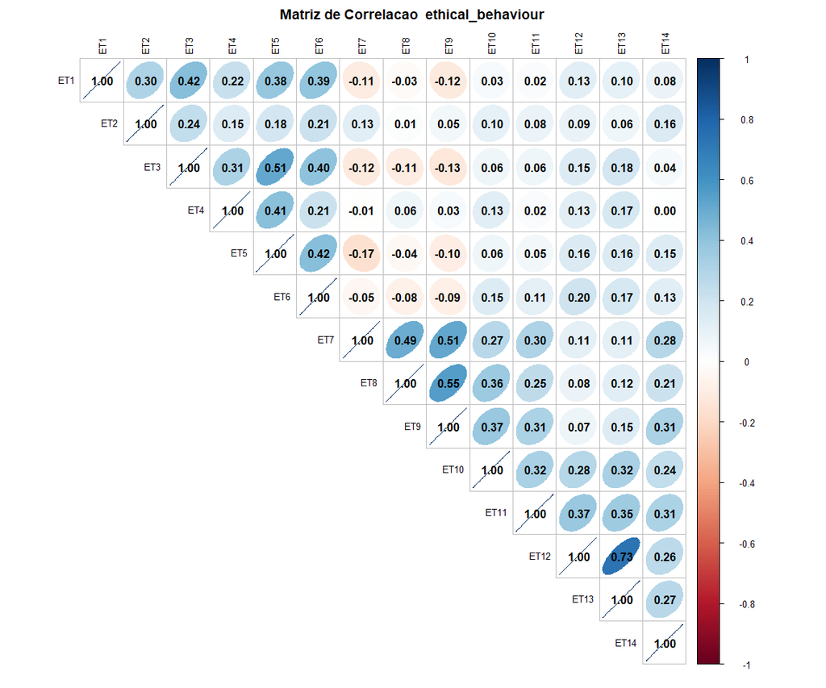

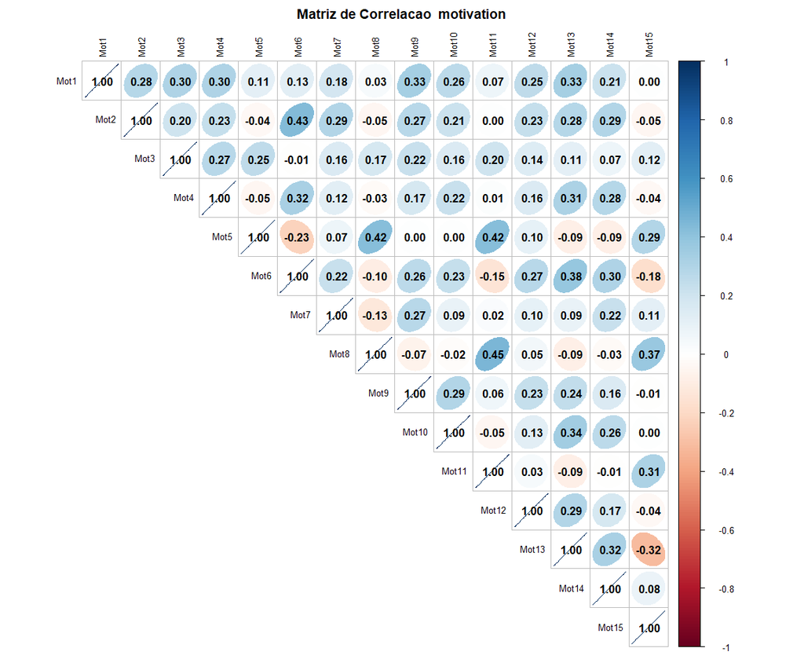

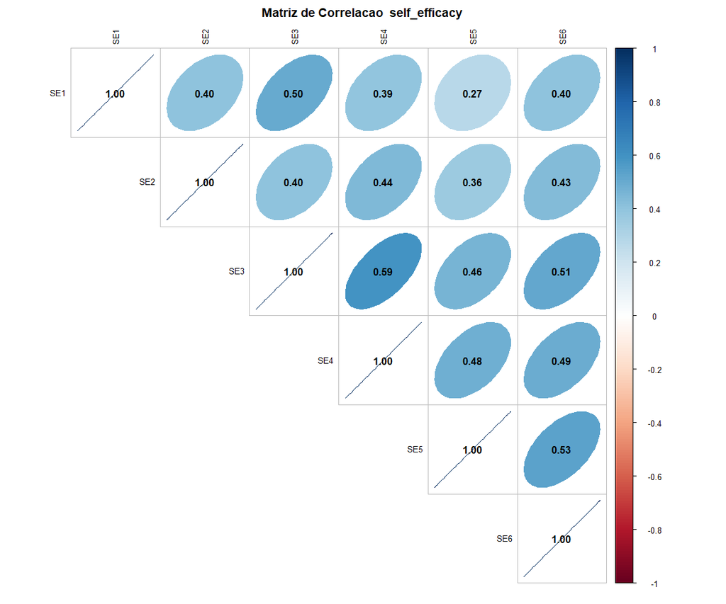

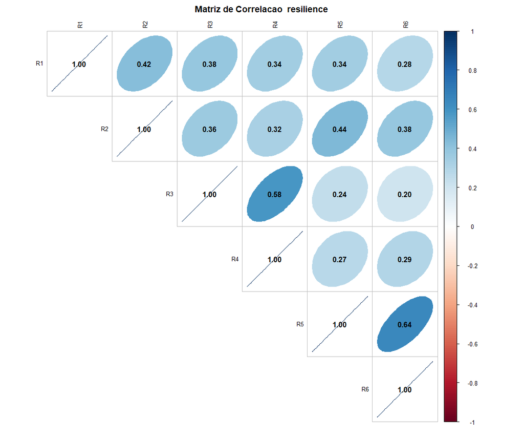

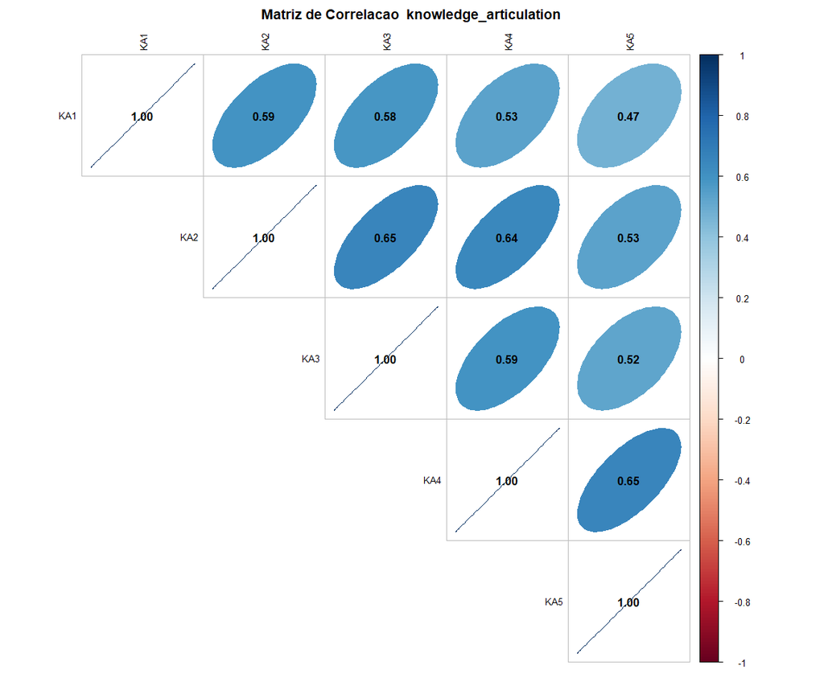

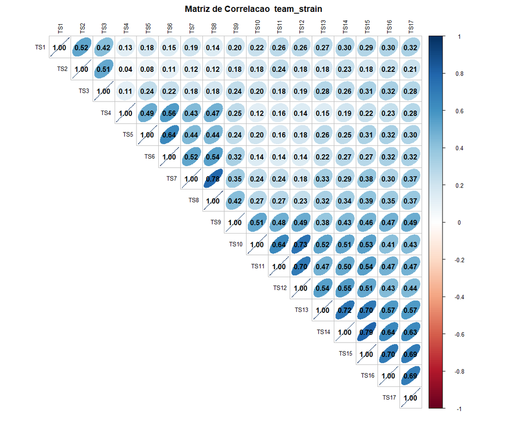

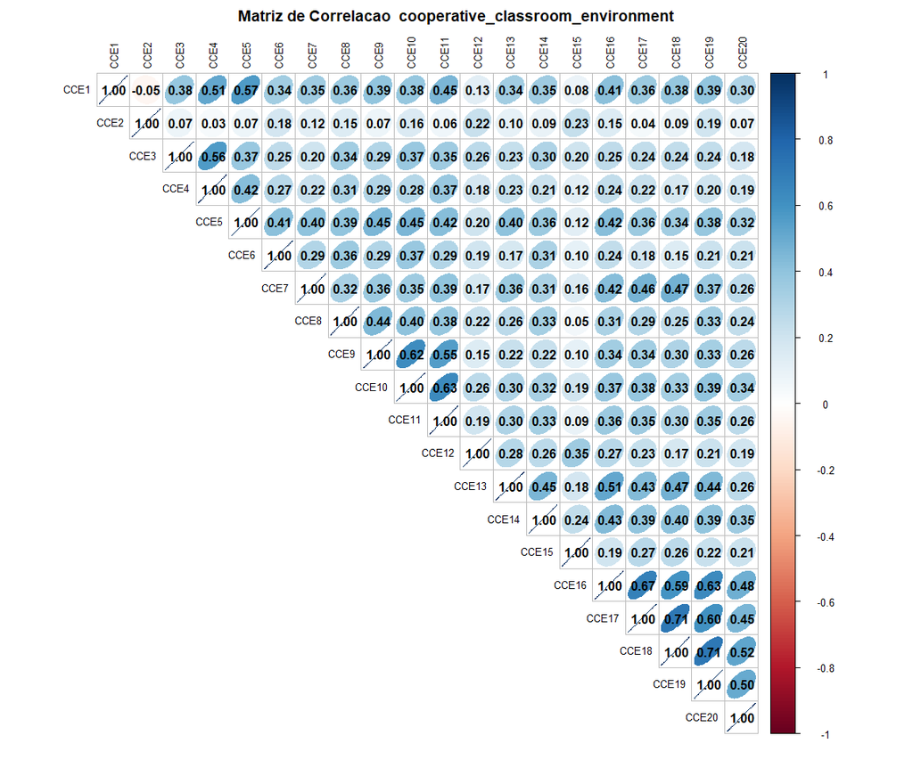

```r
construct_patterns <- list(
  ethical_behaviour = "^ET[1-9]$|^ET1[0-4]$",
  motivation = "^Mot[1-9]$|^Mot1[0-5]$",
  self_efficacy = "^SE[1-6]$",
  resilience = "^R[1-6]$",
  knowledge_articulation = "^KA[1-5]$",
  team_strain = "^TS[1-9]$|^TS1[0-7]$",
  cooperative_classroom_environment = "^CCE[1-9]$|^CCE1[0-9]$|^CCE20$"
)

for (name in names(construct_patterns)) {
  pattern <- construct_patterns[[name]]
  dataset <- df_transform %>% dplyr::select(matches(pattern))

  if (ncol(dataset) >= 2) {
    corr_matrix <- round(cor(dataset, use = "pairwise.complete.obs"), 2)

    corrplot(corr_matrix,
             method = "ellipse",
             type = "upper",
             tl.col = "black",
             tl.cex = 0.8,
             addCoef.col = "black",
             number.cex = 1.0,
             mar = c(1, 1, 2, 1),
             title = paste("Matriz de Correlacao ", name))
  }
}
```

#### Ver loadings e alpha de Cronbach

Para cada grupo de variáveis, vamos calcular o alpha de Cronbach e os loadings. O alpha de Cronbach é uma medida de consistência interna, enquanto os loadings são as cargas fatoriais que indicam a relação entre as variáveis observadas e o fator latente a ser criado.

```r
calculate_metrics_all <- function(df, construct_patterns) {
  results <- list()

  for (name in names(construct_patterns)) {
    pattern <- construct_patterns[[name]]
    dataset <- df %>% dplyr::select(matches(pattern))

    if (ncol(dataset) >= 2) {
      alpha_result <- alpha(dataset)
      cronbach_alpha <- alpha_result$total$raw_alpha

      fa_result <- fa(dataset, nfactors = 1, rotate = "none")
      loadings <- fa_result$loadings[, 1]

      results[[name]] <- list(
        construct = name,
        cronbach_alpha = cronbach_alpha,
        loadings = loadings
      )
    }
  }

  for (metric in results) {
    cat("\nConstruct: ", metric$construct, "\n")
    cat("Cronbach Alpha: ", round(metric$cronbach_alpha, 2), "\n")
    cat("Factor Loadings:\n")
    print(round(metric$loadings, 2))
  }

  return(results)
}
```

Vamos primeiro experimentar com todas as variáveis dos itens que são citados no artigo. Após isso, experimentamos com aquelas que são mencionadas no artigo para fazer os construtos.

```r
metrics_results <- calculate_metrics_all(vars_artigo, construct_patterns)
```

```
## Some items ( Mot5 Mot8 Mot11 Mot15 ) were negatively correlated with the first principal component and
## probably should be reversed.
## To do this, run the function again with the 'check.keys=TRUE' option
## Construct:  ethical_behaviour
## Cronbach Alpha:  0.73
## Factor Loadings:
##  ET1  ET2  ET3  ET4  ET5  ET6  ET7  ET8  ET9 ET10 ET11 ET12 ET13 ET14
## 0.26 0.27 0.30 0.28 0.32 0.34 0.36 0.37 0.39 0.54 0.53 0.60 0.63 0.47
##
## Construct:  motivation
## Cronbach Alpha:  0.68
## Factor Loadings:
##  Mot1  Mot2  Mot3  Mot4  Mot5  Mot6  Mot7  Mot8  Mot9 Mot10 Mot11 Mot12 Mot13
##  0.50  0.57  0.28  0.49 -0.08  0.58  0.34 -0.11  0.49  0.46 -0.06  0.41  0.61
## Mot14 Mot15
##  0.48 -0.13
##
## Construct:  self_efficacy
## Cronbach Alpha:  0.82
## Factor Loadings:
##  SE1  SE2  SE3  SE4  SE5  SE6
## 0.57 0.59 0.76 0.74 0.63 0.71
##
## Construct:  resilience
## Cronbach Alpha:  0.78
## Factor Loadings:
##   R1   R2   R3   R4   R5   R6
## 0.58 0.65 0.57 0.58 0.65 0.60
##
## Construct:  knowledge_articulation
## Cronbach Alpha:  0.87
## Factor Loadings:
##  KA1  KA2  KA3  KA4  KA5
## 0.70 0.81 0.77 0.81 0.70
##
## Construct:  team_strain
## Cronbach Alpha:  0.89
## Factor Loadings:
##  TS1  TS2  TS3  TS4  TS5  TS6  TS7  TS8  TS9 TS10 TS11 TS12 TS13 TS14 TS15 TS16
## 0.40 0.31 0.40 0.39 0.46 0.47 0.53 0.57 0.63 0.65 0.65 0.66 0.73 0.78 0.82 0.74
## TS17
## 0.76
##
## Construct:  cooperative_classroom_environment
## Cronbach Alpha:  0.89
## Factor Loadings:
##  CCE1  CCE2  CCE3  CCE4  CCE5  CCE6  CCE7  CCE8  CCE9 CCE10 CCE11 CCE12 CCE13
##  0.63  0.17  0.49  0.47  0.66  0.44  0.58  0.54  0.58  0.66  0.62  0.36  0.58
## CCE14 CCE15 CCE16 CCE17 CCE18 CCE19 CCE20
##  0.57  0.29  0.72  0.70  0.68  0.70  0.55
```

```r
selected_construct_patterns <- list(
  ethical_behaviour = c("ET12", "ET13"),
  motivation = c("Mot5", "Mot8", "Mot11"),
  self_efficacy = c("SE1", "SE2", "SE3", "SE4", "SE5", "SE6"),
  resilience = c("R2", "R5", "R6"),
  knowledge_articulation = c("KA1", "KA2", "KA3", "KA4", "KA5"),
  team_strain = c("TS10", "TS11", "TS12", "TS13", "TS14", "TS15", "TS16", "TS17"),
  cooperative_classroom_environment = c("CCE1", "CCE3", "CCE4", "CCE5", "CCE8", "CCE9","CCE10", "CCE11")
)
metrics_results <- calculate_metrics_all(vars_artigo, selected_construct_patterns)
```

```
##
## Construct:  ethical_behaviour
## Cronbach Alpha:  0.84
## Factor Loadings:
## ET12 ET13
## 0.85 0.85
##
## Construct:  motivation
## Cronbach Alpha:  0.69
## Factor Loadings:
##  Mot5  Mot8 Mot11
##  0.63  0.67  0.67
##
## Construct:  self_efficacy
## Cronbach Alpha:  0.82
## Factor Loadings:
##  SE1  SE2  SE3  SE4  SE5  SE6
## 0.57 0.59 0.76 0.74 0.63 0.71
##
## Construct:  resilience
## Cronbach Alpha:  0.74
## Factor Loadings:
##   R2   R5   R6
## 0.51 0.86 0.74
##
## Construct:  knowledge_articulation
## Cronbach Alpha:  0.87
## Factor Loadings:
##  KA1  KA2  KA3  KA4  KA5
## 0.70 0.81 0.77 0.81 0.70
##
## Construct:  team_strain
## Cronbach Alpha:  0.91
## Factor Loadings:
## TS10 TS11 TS12 TS13 TS14 TS15 TS16 TS17
## 0.70 0.70 0.72 0.78 0.84 0.86 0.74 0.74
##
## Construct:  cooperative_classroom_environment
## Cronbach Alpha:  0.88
## Factor Loadings:
##  CCE1 CCE10 CCE11 CCE12 CCE13 CCE14 CCE15 CCE16 CCE17 CCE18 CCE19  CCE3  CCE4
##  0.64  0.65  0.63  0.36  0.59  0.57  0.29  0.71  0.69  0.67  0.69  0.51  0.48
##  CCE5  CCE8  CCE9
##  0.66  0.53  0.59
```

### Análise das variáveis

#### Construtos criados no artigo

Ainda, temos acesso aos construtos criados pelos autores do artigo após a fase de análise fatorial. Vamos selecionar estas variáveis e guardá-las num objeto. Os construtos estão referidos na **Table 9** do artigo.

```r
construtos_autores <- df_transform[, 121:127]
construtos_autores
```

| ethics | Motivation | Resilience | SelfEfficacy | TeamStrain | KnowledgeArticulation | CoopClass |
| --- | --- | --- | --- | --- | --- | --- |
| 3.5 | 2.000000 | 4.000000 | 3.666667 | 3.125 | 3.6 | 3.750 |
| 5.0 | 3.000000 | 4.333333 | 4.000000 | 3.625 | 4.2 | 4.000 |
| 1.0 | 1.333333 | 5.000000 | 5.000000 | 4.000 | 4.2 | 4.125 |
| 2.0 | 3.000000 | 3.000000 | 3.000000 | 3.000 | 3.0 | 3.000 |
| 4.0 | 2.333333 | 4.000000 | 3.666667 | 3.625 | 2.8 | 3.875 |
| 3.5 | 2.333333 | 4.000000 | 3.833333 | 4.000 | 3.4 | 3.875 |
| 5.0 | 3.000000 | 4.333333 | 4.000000 | 3.625 | 4.2 | 4.000 |
| 3.5 | 4.000000 | 5.000000 | 4.000000 | 4.000 | 3.8 | 3.625 |
| 3.0 | 2.666667 | 2.666667 | 3.166667 | 3.000 | 4.0 | 3.625 |
| 4.0 | 3.333333 | 5.000000 | 3.666667 | 4.000 | 4.0 | 4.500 |

[output cut: 556 more lines]

#### Variáveis descritivas

Guardamos agora 8 variáveis do início do dataset que parecem ser apenas descritivas e que são referidas (algumas destas) no artigo, na tabela com as correlações. As correlações entre construtos pode ser encontrada na **Table 10** do artigo.

Uma destas variáveis é a `Fak` que já foi tratada anteriormente. Esta será incluída juntamente com as outras 7 e já terá os nomes alterados.

```r
descritivas <- df_transform[, 1:8]
descritivas
```

| Gender | Tlahir | BLhair | Pengeluaran | Status | Fak | IPK | Semester |
| --- | --- | --- | --- | --- | --- | --- | --- |
| 1 | 2000 | 2 | 1 | 2 | Economic | 4 | 1 |
| 1 | 2000 | 1 | 2 | 2 | Economic | 4 | 1 |
| 2 | 2000 | 10 | 2 | 2 | Economic | 4 | 1 |
| 1 | 2000 | 6 | 2 | 2 | Economic | 3 | 1 |
| 2 | 2000 | 9 | 1 | 2 | Mathematics and Natural Science | 3 | 1 |
| 1 | 2000 | 5 | 1 | 2 | Economic | 4 | 1 |
| 1 | 2000 | 1 | 2 | 2 | Economic | 4 | 1 |
| 1 | 1999 | 3 | 2 | 2 | Art | 4 | 1 |
| 1 | 2000 | 8 | 1 | 2 | Economic | 4 | 1 |
| 2 | 2000 | 6 | 4 | 2 | Mathematics and Natural Science | 2 | 1 |

[output cut: 556 more lines]

```r
skimr::skim(descritivas)$skim_variable
```

```
## [1] "Fak"         "Gender"      "Tlahir"      "BLhair"      "Pengeluaran"
## [6] "Status"      "IPK"         "Semester"
```

```r
skimr::skim(descritivas)$numeric.p0
```

```
## [1]   NA    1 1995    0    1    1    1    1
```

```r
skimr::skim(descritivas)$numeric.p100
```

```
## [1]       NA        2 31031999       12        5        3        4        6
```

Após alguma pesquisa fomos tentar verificar o que representavam estas variáveis.

- **Género**:Género da pessoa (pode ser 1 ou 2). À partida não sabemos qual corresponde ao feminino e ao masculino.
- **Tlahir**: Em indonésio pode ser uma abreviatura de Tanggal Lahir, que significa data de nascimento.
- **BLhair**: Em indonésio pode ser uma abreviatura de Bulan Lahir, que significa mês de nascimento.
- *Pengeluaran**: Em indonésio pode ser uma abreviatura de Pengeluaran, que significa despesas. Tradução direta para inglês $rightarrow$ Expenditure.

Verificamos o mínimo e o máximo de cada variável descritiva e percebemos alguns valores estranhos, dado o contexto pesquisado. Um deles é por exemplo o `Tlahir`. Talvez o valor mais alto $\rightarrow 31031999$ corresponde a $31/03/1999$. Para além disso o mês `BLhair` tem valores de 0 a 12, pelo que o 0 não faz muito sentido.

```r
# ver todos os valores de Tlahir sorted descrescente
descritivas %>%
  dplyr::select(Tlahir) %>%
  dplyr::arrange(desc(Tlahir)) %>%
  dplyr::distinct() %>%
  dplyr::filter(Tlahir > 0) # ver os valores
```

| Tlahir |
| --- |
| 31031999 |
| 16122000 |
| 11042000 |
| 302000 |
| 261998 |
| 241998 |
| 231997 |
| 221998 |
| 202000 |
| 200399 |

[output cut: 11 more lines]

- 31031999 $\rightarrow$ 1999
- 16122000 $\rightarrow$ 2000
- 11042000 $\rightarrow$ 2000
- 302000 $\rightarrow$ 2000
- 261998 $\rightarrow$ 1998
- 241998 $\rightarrow$ 1998
- 231997 $\rightarrow$ 1997
- 221998 $\rightarrow$ 1998
- 202000 $\rightarrow$ 2000
- 200399 $\rightarrow$ 1999 (talvez é 20/03/99)
- 81999 $\rightarrow$ 1999
- 71999 $\rightarrow$ 1999
- 20000 $\rightarrow$ 2000
- 3200 $\rightarrow$ 2000 (talvez é 3/2/00)

```r
descritivas <- descritivas %>%
  mutate(Tlahir = case_when(
    Tlahir == 31031999 ~ 1999,
    Tlahir == 16122000 ~ 2000,
    Tlahir == 11042000 ~ 2000,
    Tlahir == 302000   ~ 2000,
    Tlahir == 261998   ~ 1998,
    Tlahir == 241998   ~ 1998,
    Tlahir == 231997   ~ 1997,
    Tlahir == 221998   ~ 1998,
    Tlahir == 202000   ~ 2000,
    Tlahir == 200399   ~ 1999,
    Tlahir == 81999    ~ 1999,
    Tlahir == 71999    ~ 1999,
    Tlahir == 20000    ~ 2000,
    Tlahir == 3200     ~ 2000,
    TRUE ~ as.numeric(Tlahir)  # mantém outros valores como estão
  ))
```

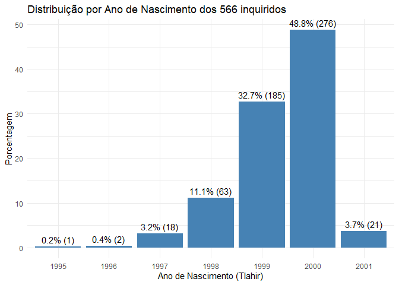

```r
descritivas %>%
  group_by(Tlahir) %>%
  summarise(Count = n()) %>%
  mutate(Percentage = Count / sum(Count) * 100) %>%
  ggplot(aes(x = factor(Tlahir), y = Percentage)) +
  geom_bar(stat = "identity", fill = "steelblue") +
  geom_text(aes(label = paste0(round(Percentage, 1), "% (", Count, ")")), vjust = -0.5) +
  labs(x = "Ano de Nascimento (Tlahir)", y = "Porcentagem", title = "Distribuição por Ano de Nascimento dos 566 inquiridos") +
  theme_minimal()
```

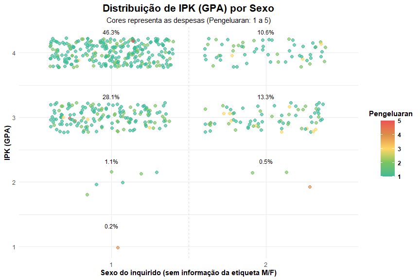

```r
df_percent <- df %>%
  group_by(Gender, IPK) %>%
  summarise(Count = n(), .groups = "drop") %>%
  mutate(Percentage = round(Count / sum(Count) * 100, 1))


ggplot(descritivas, aes(x = as.factor(Gender), y = IPK, color = Pengeluaran)) +
  geom_jitter(width = 0.4, height = 0.23, alpha = 0.67, size = 2.0) +
  geom_text(data = df_percent, aes(x = as.factor(Gender), y = as.numeric(IPK) + 0.2,
                                   label = paste0(Percentage, "%")),
            color = "black", size = 3.2, vjust = -1.2, inherit.aes = FALSE) +
  geom_vline(xintercept = 1.5, linetype = "dashed", color = "grey85", linewidth = 0.3) +
  scale_color_gradientn(colors = c("#3CBA96", "#78C461", "#FFD666", "#DD8D4A" ,"#EC5353"), name = "Pengeluaran") +
  scale_x_discrete(limits = c("1", "2"), labels = c("1" = "1", "2" = "2")) +
  labs(
    x = "Sexo do inquirido (sem informação da etiqueta M/F)",
    y = "IPK (GPA)",
    title = "Distribuição de IPK (GPA) por Sexo",
    subtitle = "Cores representa as despesas (Pengeluaran: 1 a 5)"
  ) +
  theme_minimal() +
  theme(
  plot.title = element_text(hjust = 0.5, face = "bold", size = 16),
  plot.subtitle = element_text(hjust = 0.5),
  legend.title = element_text(face = "bold"),
  legend.title.align = 0.5,
  legend.text = element_text(face = "bold"),
  legend.key.width = unit(1.5, "lines"),
  legend.spacing.x = unit(0.3, "cm"),
  axis.title.x = element_text(face = "bold"),
  axis.title.y = element_text(face = "bold"),
  axis.text.x = element_text(angle = 0, hjust = 0.5)
)
```

```r
# ggsave("ipk_genero_plot.png", width = 9, height = 6, dpi = 300)
```

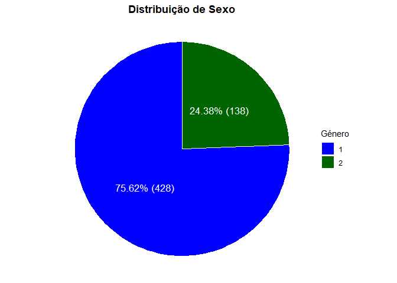

```r
df_gender <- descritivas %>%
  count(Gender) %>%
  mutate(
    Percentage = round(n / sum(n) * 100, 2),
    Label = paste0(Percentage, "% (", n, ")")
  )

ggplot(df_gender, aes(x = "", y = n, fill = as.factor(Gender))) +
  geom_bar(stat = "identity", width = 1, color = "white") +
  coord_polar(theta = "y") +
  geom_text(aes(label = Label), position = position_stack(vjust = 0.5), color = "white", size = 4.5) +
  scale_fill_manual(
    values = c("1" = "blue",  # Roxo
               "2" = "darkgreen"), # Amarelo
    name = "Género",
    labels = c("1" = "1", "2" = "2")
  ) +
  labs(title = "Distribuição de Sexo") +
  theme_void() +
  theme(plot.title = element_text(hjust = 0.5, face = "bold"))
```

#### Variáveis não citadas no artigo

As colunas que não estão nos outros datasets.

```r
# selecionar do dataset df_transform aquelas que não estao em descritivas, vars_artigo e construtos_autores
vars_nao_citadas <- df_transform %>%
  dplyr::select(-all_of(c(colnames(descritivas), colnames(vars_artigo), colnames(construtos_autores))))
vars_nao_citadas
```

| POP1 | POP2 | POP3 | POP4 | POP5 | POP6 | POP7 | POP8 | POP9 | PC1 | PC2 | PC3 | PC4 | PC5 | PC6 | Opt1 | Opt2 | Opt3 | Opt4 | Opt5 | Opt6 | INO1 | INO2 | INO3 | INO4 | INO5 | PDC1 | PDC2 | PDC3 |
| --- | --- | --- | --- | --- | --- | --- | --- | --- | --- | --- | --- | --- | --- | --- | --- | --- | --- | --- | --- | --- | --- | --- | --- | --- | --- | --- | --- | --- |
| 4 | 4 | 4 | 4 | 4 | 4 | 4 | 4 | 1 | 4 | 4 | 4 | 3 | 4 | 4 | 3 | 4 | 3 | 4 | 4 | 4 | 4 | 3 | 3 | 3 | 3 | 4 | 4 | 3 |
| 4 | 4 | 4 | 3 | 3 | 4 | 4 | 3 | 3 | 4 | 5 | 5 | 3 | 4 | 3 | 3 | 4 | 3 | 3 | 3 | 3 | 4 | 4 | 4 | 4 | 4 | 4 | 4 | 4 |
| 5 | 5 | 5 | 1 | 1 | 5 | 1 | 3 | 1 | 5 | 5 | 5 | 5 | 5 | 5 | 1 | 5 | 1 | 5 | 5 | 5 | 5 | 4 | 5 | 5 | 5 | 4 | 5 | 5 |
| 4 | 4 | 3 | 3 | 3 | 5 | 5 | 3 | 3 | 3 | 3 | 3 | 3 | 3 | 3 | 3 | 3 | 3 | 3 | 3 | 3 | 4 | 4 | 2 | 3 | 3 | 3 | 3 | 3 |
| 2 | 3 | 3 | 4 | 3 | 4 | 4 | 3 | 3 | 4 | 4 | 4 | 3 | 4 | 4 | 3 | 4 | 3 | 4 | 4 | 3 | 4 | 4 | 4 | 3 | 3 | 4 | 4 | 4 |
| 5 | 4 | 4 | 4 | 4 | 4 | 4 | 4 | 2 | 5 | 5 | 5 | 3 | 5 | 3 | 5 | 5 | 4 | 4 | 5 | 4 | 4 | 4 | 3 | 4 | 4 | 3 | 5 | 5 |
| 4 | 4 | 4 | 3 | 3 | 4 | 4 | 3 | 3 | 4 | 5 | 5 | 3 | 4 | 3 | 3 | 4 | 3 | 3 | 3 | 3 | 4 | 4 | 4 | 4 | 4 | 4 | 4 | 4 |
| 4 | 3 | 4 | 4 | 3 | 4 | 4 | 4 | 4 | 4 | 4 | 4 | 4 | 4 | 4 | 4 | 4 | 4 | 4 | 4 | 4 | 3 | 2 | 4 | 3 | 3 | 3 | 4 | 4 |
| 1 | 1 | 3 | 1 | 4 | 4 | 2 | 1 | 1 | 4 | 4 | 4 | 3 | 4 | 3 | 1 | 1 | 4 | 3 | 4 | 3 | 4 | 3 | 4 | 4 | 4 | 4 | 4 | 4 |
| 4 | 4 | 4 | 2 | 2 | 4 | 4 | 3 | 2 | 3 | 4 | 4 | 4 | 4 | 4 | 4 | 3 | 4 | 4 | 4 | 3 | 3 | 4 | 4 | 4 | 4 | 4 | 4 | 4 |

[output cut: 556 more lines]

Estas colunas, assim como as variáveis descritivas, vamos ignorar porque não servem para a replicação do artigo.

#### Criar próprios CFA como fazem no artigo (erradamente)

Vamos começar por fazer uma análise fatorial confirmatória (CFA) com as variáveis que foram criados pelos autores do artigo. Vamos usar a função `cfa` do pacote `lavaan`.

```r
run_CFA_extract_scores <- function(df, construtos_lista) {
  df_resultado <- data.frame(matrix(nrow = nrow(df), ncol = 0))
  modelos <- list()

  for (nome_construto in names(construtos_lista)) {
    itens <- construtos_lista[[nome_construto]]
    formula_cfa <- paste0(nome_construto, " =~ ", paste(itens, collapse = " + "))

    modelo <- cfa(formula_cfa, data = df, std.lv = TRUE)
    modelos[[nome_construto]] <- modelo

    cat("\n\n--- CFA:", nome_construto, "---\n")
    print(summary(modelo, standardized = TRUE, rsquare = TRUE))

    loadings <- parameterEstimates(modelo) %>% filter(op == "=~")
    print(loadings)

    # CFA scores
    scores <- lavPredict(modelo)
    if (is.vector(scores)) {
      df_resultado[[paste0("score_", nome_construto)]] <- scores
    } else if (is.matrix(scores)) {
      df_resultado[[paste0("score_", nome_construto)]] <- scores[, 1]
    }
  }

  return(list(scores_df = df_resultado, modelos = modelos))
}

construtos <- list(
  factor_Ethics = c("ET12", "ET13"),
  factor_Motivation = c("Mot5", "Mot8", "Mot11"),
  factor_SelfEfficacy = c("SE1", "SE2", "SE3", "SE4", "SE5", "SE6"),
  factor_Resilience = c("R2", "R5", "R6"),
  factor_KnowledgeArticulation = c("KA1", "KA2", "KA3", "KA4", "KA5"),
  factor_TeamStrain = c("TS10", "TS11", "TS12", "TS13", "TS14", "TS15", "TS16", "TS17"),
  factor_CooperativeClassroomEnvironment = c("CCE1", "CCE3", "CCE4", "CCE5", "CCE8", "CCE9", "CCE10", "CCE11")
)

resultado_CFA <- run_CFA_extract_scores(df, construtos)
df_OUR_CFA <- resultado_CFA$scores_df

# modelos_CFA <- resultado_CFA$modelos
```

Para além do CFA, vamos ver como seria se fizéssemos a média, pois os autores também o fazem para ter os construtos “Motivation”, “SelfEfficacy”, “Resilience”, etc.. Apenas nos apercebemos disto porque o dataset contém a informação dos construtos que os autores criaram e podemos perceber que não representavam scores, apenas uma média das variáveis. Por exemplo: Student Ethics: (ET12+ET13)/2 para cada uma das 566 linhas/respostas.

```r
run_item_means <- function(df, construtos_lista) {
  df_resultado <- data.frame(matrix(nrow = nrow(df), ncol = 0))

  for (nome_construto in names(construtos_lista)) {
    itens <- construtos_lista[[nome_construto]]

    media_itens <- rowMeans(df[, itens], na.rm = TRUE)
    df_resultado[[paste0("mean_", nome_construto)]] <- media_itens
  }
  return(df_resultado)
}

construtos <- list(
  factor_Ethics = c("ET12", "ET13"),
  factor_Motivation = c("Mot5", "Mot8", "Mot11"),
  factor_SelfEfficacy = c("SE1", "SE2", "SE3", "SE4", "SE5", "SE6"),
  factor_Resilience = c("R2", "R5", "R6"),
  factor_KnowledgeArticulation = c("KA1", "KA2", "KA3", "KA4", "KA5"),
  factor_TeamStrain = c("TS10", "TS11", "TS12", "TS13", "TS14", "TS15", "TS16", "TS17"),
  factor_CooperativeClassroomEnvironment = c("CCE1", "CCE3", "CCE4", "CCE5", "CCE8", "CCE9", "CCE10", "CCE11")
)

df_means_only <- run_item_means(df, construtos)
```

Juntar os dois datasets para serem utilizados depois.

```r
# juntar os dois dataframes
df_OUR_results <- cbind(df_OUR_CFA, df_means_only)
colnames(df_OUR_results)
```

```
##  [1] "score_factor_Ethics"
##  [2] "score_factor_Motivation"
##  [3] "score_factor_SelfEfficacy"
##  [4] "score_factor_Resilience"
##  [5] "score_factor_KnowledgeArticulation"
##  [6] "score_factor_TeamStrain"
##  [7] "score_factor_CooperativeClassroomEnvironment"
##  [8] "mean_factor_Ethics"
##  [9] "mean_factor_Motivation"
## [10] "mean_factor_SelfEfficacy"
## [11] "mean_factor_Resilience"
## [12] "mean_factor_KnowledgeArticulation"
## [13] "mean_factor_TeamStrain"
## [14] "mean_factor_CooperativeClassroomEnvironment"
```

```r
df_OUR_results
```

| score_factor_Ethics | score_factor_Motivation | score_factor_SelfEfficacy | score_factor_Resilience | score_factor_KnowledgeArticulation | score_factor_TeamStrain | score_factor_CooperativeClassroomEnvironment | mean_factor_Ethics | mean_factor_Motivation | mean_factor_SelfEfficacy | mean_factor_Resilience | mean_factor_KnowledgeArticulation | mean_factor_TeamStrain | mean_factor_CooperativeClassroomEnvironment |
| --- | --- | --- | --- | --- | --- | --- | --- | --- | --- | --- | --- | --- | --- |
| 0.46592249 | -0.88015791 | 0.223235907 | 0.383704704 | -0.56791358 | -1.3950299758 | 0.023821408 | 3.5 | 2.000000 | 3.666667 | 4.000000 | 3.6 | 3.125 | 3.750 |
| 1.88939298 | 0.28459644 | 0.601091394 | 0.546144210 | 0.39751486 | -0.0909414369 | 0.326000264 | 5.0 | 3.000000 | 4.000000 | 4.333333 | 4.2 | 3.625 | 4.000 |
| -2.33893865 | -1.68268592 | 2.395679932 | 1.718439417 | 0.91753265 | 0.3548791289 | 0.640167979 | 1.0 | 1.333333 | 5.000000 | 5.000000 | 4.2 | 4.000 | 4.125 |
| -1.28185574 | 0.32989873 | -1.193497145 | -0.951030009 | -1.64976811 | -1.5063237866 | -1.535693669 | 2.0 | 3.000000 | 3.000000 | 3.000000 | 3.0 | 3.000 | 3.000 |
| 0.83231007 | -0.48515853 | 0.022336715 | 0.383704704 | -1.90431231 | 0.0186187811 | -0.011086472 | 4.0 | 2.333333 | 3.666667 | 4.000000 | 2.8 | 3.625 | 3.875 |
| 0.46592249 | -0.53046083 | 0.416038475 | 0.617848257 | -0.84995703 | 0.3548791289 | 0.178866388 | 3.5 | 2.333333 | 3.833333 | 4.000000 | 3.4 | 4.000 | 3.875 |
| 1.88939298 | 0.28459644 | 0.601091394 | 0.546144210 | 0.39751486 | -0.0909414369 | 0.326000264 | 5.0 | 3.000000 | 4.000000 | 4.333333 | 4.2 | 3.625 | 4.000 |
| 0.14161475 | 1.44935078 | 0.601091394 | 1.718439417 | -0.11157353 | 0.3548791289 | -0.359585631 | 3.5 | 4.000000 | 4.000000 | 5.000000 | 3.8 | 4.000 | 3.625 |
| -0.22477283 | -0.09015916 | -1.000694577 | -1.960885710 | 0.14297066 | -1.5063237866 | -0.718389793 | 3.0 | 2.666667 | 3.166667 | 2.666667 | 4.0 | 3.000 | 3.625 |
| 0.83231007 | 0.69212507 | 0.008136104 | 1.718439417 | 0.14297066 | 0.3548791289 | 1.455887932 | 4.0 | 3.333333 | 3.666667 | 5.000000 | 4.0 | 4.000 | 4.500 |

[output cut: 556 more lines]

### Criar ficheiros csv na pasta data com os 4 conjuntos anteriores

Guardar numa pasta específica para ajudar os dados mais facilmente com a separação realizada. Isto porque algumas variáveis serão utilizadas e outras não.

```r
# escrever uma função
write_csvs <- function(data, name){
  write_csv(data, paste0("../data/4_conjuntos(dev)/", name, ".csv"))
}
write_csvs(descritivas, "descritivas")
write_csvs(vars_artigo, "vars_artigo")
write_csvs(construtos_autores, "construtos_autores")
write_csvs(vars_nao_citadas, "vars_nao_citadas")
write_csvs(df_OUR_results, "df_OUR_results")
```

## Fase 2: Replicação do artigo

Depois de percebermos o dataset que temos e o que é que os autores fizeram, vamos replicar o artigo. Vamos fazer a replicação do artigo de forma a percebermos como é que os autores chegaram aos resultados e discutir os valores obtidos do ponto de vista de Bayesiana.

### 1 - CFA para cada conjunto de questões

```r
# ler csv
df <- read.csv("../data/4_conjuntos(dev)/vars_artigo.csv")
df
```

| ET1 | ET2 | ET3 | ET4 | ET5 | ET6 | ET7 | ET8 | ET9 | ET10 | ET11 | ET12 | ET13 | ET14 | Mot1 | Mot2 | Mot3 | Mot4 | Mot5 | Mot6 | Mot7 | Mot8 | Mot9 | Mot10 | Mot11 | Mot12 | Mot13 | Mot14 | Mot15 | SE1 | … |
| --- | --- | --- | --- | --- | --- | --- | --- | --- | --- | --- | --- | --- | --- | --- | --- | --- | --- | --- | --- | --- | --- | --- | --- | --- | --- | --- | --- | --- | --- | --- |
| 1 | 4 | 4 | 3 | 1 | 1 | 3 | 3 | 4 | 4 | 4 | 3 | 4 | 4 | 3 | 4 | 4 | 4 | 2 | 4 | 4 | 2 | 4 | 4 | 2 | 4 | 4 | 4 | 2 | 3 | … |
| 1 | 2 | 1 | 2 | 2 | 2 | 5 | 5 | 5 | 5 | 5 | 5 | 5 | 4 | 4 | 4 | 4 | 5 | 3 | 5 | 4 | 3 | 4 | 4 | 3 | 4 | 5 | 5 | 1 | 4 | … |
| 1 | 1 | 1 | 5 | 1 | 1 | 5 | 5 | 5 | 1 | 1 | 1 | 1 | 1 | 4 | 5 | 2 | 2 | 2 | 5 | 5 | 1 | 1 | 5 | 1 | 4 | 5 | 5 | 1 | 5 | … |
| 1 | 4 | 1 | 1 | 1 | 3 | 4 | 4 | 5 | 5 | 4 | 2 | 2 | 2 | 4 | 4 | 4 | 3 | 2 | 4 | 2 | 4 | 3 | 3 | 3 | 4 | 5 | 3 | 1 | 3 | … |
| 3 | 3 | 2 | 3 | 3 | 3 | 4 | 4 | 5 | 4 | 4 | 4 | 4 | 3 | 4 | 3 | 2 | 4 | 2 | 4 | 4 | 2 | 4 | 3 | 3 | 4 | 4 | 4 | 3 | 4 | … |
| 2 | 3 | 1 | 2 | 2 | 2 | 4 | 4 | 4 | 2 | 3 | 3 | 4 | 5 | 4 | 4 | 3 | 3 | 3 | 4 | 4 | 1 | 4 | 3 | 3 | 4 | 5 | 4 | 1 | 4 | … |
| 1 | 2 | 1 | 2 | 2 | 2 | 5 | 5 | 5 | 5 | 5 | 5 | 5 | 4 | 4 | 4 | 4 | 5 | 3 | 5 | 4 | 3 | 4 | 4 | 3 | 4 | 5 | 5 | 1 | 4 | … |
| 4 | 4 | 3 | 4 | 4 | 3 | 4 | 4 | 4 | 5 | 3 | 4 | 3 | 4 | 4 | 4 | 4 | 4 | 4 | 4 | 4 | 4 | 4 | 4 | 4 | 4 | 4 | 4 | 5 | 4 | … |
| 1 | 4 | 4 | 4 | 1 | 1 | 4 | 4 | 4 | 4 | 3 | 3 | 3 | 4 | 5 | 5 | 3 | 4 | 2 | 4 | 3 | 2 | 4 | 4 | 4 | 5 | 5 | 4 | 1 | 4 | … |
| 2 | 5 | 2 | 3 | 3 | 3 | 5 | 5 | 4 | 5 | 4 | 4 | 4 | 5 | 4 | 4 | 4 | 4 | 3 | 5 | 4 | 4 | 5 | 5 | 3 | 5 | 5 | 5 | 3 | 4 | … |

[output cut: 556 more lines]

Como primeira análise vamos fazer uma análise fatorial confirmatória (CFA) para tentar verificar se as variáveis utilizadas nos construtos são as que têm valores de loadings mais elevados. Vamos usar o pacote `blavaan` para fazer a modelação bayesiana.

```r
# individual params
n_chains <- 3 # 5
burn_in <- 1500
sample_estimate <- 3000
```

A função `bcfa` do pacote `blavaan` é utilizada para fazer a modelação bayesiana. Esta função tem como parâmetros o modelo, os dados, o número de cadeias, o burn-in e o número de amostras.

Vamos fazer o semplot para ver os resultados da modelação. O semPaths é uma função do pacote `semPlot` que permite visualizar os resultados da modelação.

```r
plot_sem_model <- function(model, title = "") {
  semPaths(model,
           what = "std",
           layout = "spring",
           edge.label.cex = 0.6,
           sizeMan = 3,
           sizeLat = 7,
           nCharNodes = 4,
           residuals = TRUE,
           intercepts = FALSE,
           optimizeLatRes = TRUE,
           edge.color = "darkgreen",
           color = list(lat = "skyblue", man = "white"),
           node.width = 2,
           mar = c(6, 6, 6, 6))
}
```

Já fizemos uma análise fatorial confirmatória (CFA) para tentar verificar se as variáveis utilizadas nos construtos são as que têm valores de loadings mais elevados. Vamos usar o pacote `blavaan` para fazer a modelação bayesiana de cada grupo de variáveis em separado.

Para isso vamos seguir três abordagens:

- A primeira abordagem com todas as variáveis para cada construto a ser constituído;
- A segunda abordagem será com as variáveis consideradas no artigo para a formação dos construtos;
- A terceira abordagem com as variáveis que têm os loadings mais elevados para cada construto a ser constituído.

#### CFA com todas as variáveis para tentar justificar/perceber as escolhas para os construtos

Esta é a primeira abordagem em que vamos verificar os valores dos loadings e tentar justificar as escolhas dos autores.

**Nota**: é necessário ter em conta que os autores não utilizaram todas as variáveis para a formação dos construtos e podem ter optado por algumas pelos valores dos loadings ou pelas perguntas que fariam mais sentido dado o questionário. Levaremos isso em conta.

##### Student Ethics

```r
if(correr_single_CFAs_all){
  # Student Ethics
  model.ethics <- 'StudentEthics =~ ET1 + ET2 + ET3 + ET4 + ET5 + ET6 + ET7 +
                                    ET8 + ET9 + ET10 + ET11 + ET12 + ET13 + ET14'
  fit.ethics <- bcfa(model.ethics, data = df, std.lv = TRUE,
                        n.chains = n_chains, burnin=burn_in,
                        sample=sample_estimate, target = "stan")
  summary(fit.ethics, standardized = TRUE, rsquare = TRUE)
  fitMeasures(fit.ethics)
}
```

1500 burn-in + 3000 samples

| Item | Loadings |
| --- | --- |
| ET1 | 0.183 |
| ET2 | 0.244 |
| ET3 | 0.258 |
| ET4 | 0.221 |
| ET5 | 0.275 |
| ET6 | 0.288 |
| ET7 | 0.198 |
| ET8 | 0.194 |
| ET9 | 0.190 |
| ET10 | 0.395 |
| ET11 | 0.411 |
| ET12 | **0.741** |
| ET13 | **0.749** |
| ET14 | 0.364 |

O artigo opta por selecionar apenas 2 variáveis para o `Student Ethics` (ET12 e ET13), que são os que têm os loadings mais expressivos! Por isso, acabamos por concordar e não vamos incluir ou excluir variáveis.

##### Motivation

```r
if(correr_single_CFAs_all){
  # Motivation
  model.motivation <- 'Motivation =~ Mot1 + Mot2 + Mot3 + Mot4 + Mot5 +
                                    Mot6 + Mot7 + Mot8 + Mot9 + Mot10 +
                                    Mot11 + Mot12 + Mot13 + Mot14 +
                                    Mot15'
  fit.motivation <- bcfa(model.motivation, data = df, std.lv = TRUE,
                        n.chains = n_chains, burnin=burn_in,
                        sample=sample_estimate, target = "stan")
  summary(fit.motivation, standardized = TRUE, rsquare = TRUE)
  fitMeasures(fit.motivation)
}
```

1500 burn-in + 3000 samples

| Item | Loadings |
| --- | --- |
| Mot1 | 0.364 |
| Mot2 | 0.386 |
| Mot3 | 0.244 |
| Mot4 | 0.368 |
| Mot5 | -0.078 |
| Mot6 | 0.409 |
| Mot7 | 0.259 |
| Mot8 | -0.101 |
| Mot9 | 0.354 |
| Mot10 | 0.318 |
| Mot11 | -0.058 |
| Mot12 | 0.285 |
| Mot13 | 0.422 |
| Mot14 | 0.354 |
| Mot15 | -0.165 |

O artigo opta por selecionar apenas 3 variáveis para o `Motivation` (Mot5, Mot8 e Mot11), que são os que têm os loadings negativos, a par do Mot15. São as três variáveis que têm os loadings mais parto de 0 (com diferença menor que 0.1), que talvez seja uma forma de tentar perceber a relação entre a pouca motivação e a ética.

##### Self-Efficacy

```r
if(correr_single_CFAs_all){
  # Self-Efficacy
  model.efficacy <- 'SelfEfficacy =~ SE1 + SE2 + SE3 + SE4 + SE5 + SE6'
  fit.efficacy <- bcfa(model.efficacy, data = df, std.lv = TRUE,
                        n.chains = n_chains, burnin=burn_in,
                        sample=sample_estimate, target = "stan")
  summary(fit.efficacy, standardized = TRUE, rsquare = TRUE)
  fitMeasures(fit.efficacy)
}
```

1500 burn-in + 3000 samples

| Item | Loadings |
| --- | --- |
| SE1 | 0.414 |
| SE2 | 0.447 |
| SE3 | 0.514 |
| SE4 | 0.494 |
| SE5 | 0.441 |
| SE6 | 0.458 |

Optam-se por utilizar todas as variáveis para o `Self Efficacy`, dado que todas têm loadings positivos e acima de 0.4.

##### Resilience

```r
if(correr_single_CFAs_all){
  # Resilience
  model.resilience <- 'Resilience =~ R1 + R2 + R3 + R4 + R5 + R6'
  fit.resilience <- bcfa(model.resilience, data = df, std.lv = TRUE,
                        n.chains = n_chains, burnin=burn_in,
                        sample=sample_estimate, target = "stan")
  summary(fit.resilience, standardized = TRUE, rsquare = TRUE)
  fitMeasures(fit.resilience)
}
```

1500 burn-in + 3000 samples

| Item | Loadings |
| --- | --- |
| R1 | 0.438 |
| R2 | 0.501 |
| R3 | 0.356 |
| R4 | 0.381 |
| R5 | 0.548 |
| R6 | 0.485 |

O artigo opta por selecionar 3 variáveis para o `Resilience` (R2, R5 e R6), que são os que têm os loadings mais expressivos (os três arredondados são acima 0.5).

##### Knowledge Articulation

```r
if(correr_single_CFAs_all){
  # Knowledge Articulation
  model.knowledge <- 'KnowledgeArticulation =~ KA1 + KA2 + KA3 + KA4 + KA5'
  fit.knowledge <- bcfa(model.knowledge, data = df, std.lv = TRUE,
                        n.chains = n_chains, burnin=burn_in,
                        sample=sample_estimate, target = "stan")
  summary(fit.knowledge, standardized = TRUE, rsquare = TRUE)
  fitMeasures(fit.knowledge)
}
```

1500 burn-in + 3000 samples

| Item | Loadings |
| --- | --- |
| KA1 | 0.476 |
| KA2 | 0.521 |
| KA3 | 0.476 |
| KA4 | 0.510 |
| KA5 | 0.449 |

O artigo opta por selecionar todas as variáveis para o `Knowledge Articulation`, dado que todas têm loadings positivos e acima de 0.4.

##### Team Strain

```r
if(correr_single_CFAs_all){
  # Team Strain
  model.teamstrain <- 'TeamStrain =~ TS1 + TS2 + TS3 + TS4 + TS5 +
                                    TS6 + TS7 + TS8 + TS9 + TS10 +
                                    TS11 + TS12 + TS13 + TS14 +
                                    TS15 + TS16 + TS17'
  fit.teamstrain <- bcfa(model.teamstrain, data = df, std.lv = TRUE,
                        n.chains = n_chains, burnin=burn_in,
                        sample=sample_estimate, target = "stan")
  summary(fit.teamstrain, standardized = TRUE, rsquare = TRUE)
  fitMeasures(fit.teamstrain)
}
```

1500 burn-in + 3000 samples

| Item | Loadings |
| --- | --- |
| TS1 | 0.295 |
| TS2 | 0.216 |
| TS3 | 0.266 |
| TS4 | 0.245 |
| TS5 | 0.284 |
| TS6 | 0.288 |
| TS7 | 0.350 |
| TS8 | 0.355 |
| TS9 | 0.415 |
| TS10 | 0.485 |
| TS11 | 0.491 |
| TS12 | 0.503 |
| TS13 | 0.500 |
| TS14 | 0.506 |
| TS15 | 0.549 |
| TS16 | 0.455 |
| TS17 | 0.450 |

O artigo opta por selecionar 8 variáveis para o `Team Strain` (TS10, TS11, TS12, TS13, TS14, TS15, TS16 e TS17), que são os que têm os loadings mais expressivos (os 8 arredondados são acima 0.5).

##### Cooperative Classroom Environment

```r
if(correr_single_CFAs_all){
  # Cooperative Classroom Environment
  model.cce <- 'CooperativeClassroomEnvironment =~ CCE1 + CCE2 + CCE3 +
                                    CCE4 + CCE5 + CCE6 + CCE7 + CCE8 +
                                    CCE9 + CCE10 + CCE11 + CCE12 + CCE13 +
                                    CCE14 + CCE15 + CCE16 + CCE17 + CCE18 +
                                    CCE19 + CCE20'
  fit.cce <- bcfa(model.cce, data = df, std.lv = TRUE,
                        n.chains = n_chains, burnin=burn_in,
                        sample=sample_estimate, target = "stan")
  summary(fit.cce, standardized = TRUE, rsquare = TRUE)
  fitMeasures(fit.cce)
}
```

1500 burn-in + 3000 samples

| Item | Loadings |
| --- | --- |
| CCE1 | 0.466 |
| CCE2 | 0.145 |
| CCE3 | 0.357 |
| CCE4 | 0.321 |
| CCE5 | 0.418 |
| CCE6 | 0.325 |
| CCE7 | 0.388 |
| CCE8 | 0.389 |
| CCE9 | 0.413 |
| CCE10 | 0.418 |
| CCE11 | 0.415 |
| CCE12 | 0.330 |
| CCE13 | 0.413 |
| CCE14 | 0.412 |
| CCE15 | 0.278 |
| CCE16 | 0.472 |
| CCE17 | 0.445 |
| CCE18 | 0.466 |
| CCE19 | 0.455 |
| CCE20 | 0.396 |

O artigo opta por selecionar 8 variáveis para o `Cooperative Classroom Environment` (CCE1, CCE3, CCE4, CCE5, CCE8, CCE9, CCE10 e CCE11).

##### Gráficos

Desenhar os semplots com a função definida acima.

```r
if(correr_single_CFAs_all){
  p1 <- plot_sem_model(fit.ethics, "Student Ethics")
  p2 <- plot_sem_model(fit.motivation, "Motivation")
  p3 <- plot_sem_model(fit.efficacy, "Self Efficacy")
  p4 <- plot_sem_model(fit.resilience, "Resilience")
  p5 <- plot_sem_model(fit.knowledge, "Knowledge Articulation")
  p6 <- plot_sem_model(fit.teamstrain, "Team Strain")
  p7 <- plot_sem_model(fit.cce, "Cooperative Classroom Environment")
}
```

Distribuição de N(0,10) para lambda e Gama(1,0.5) para a variância.

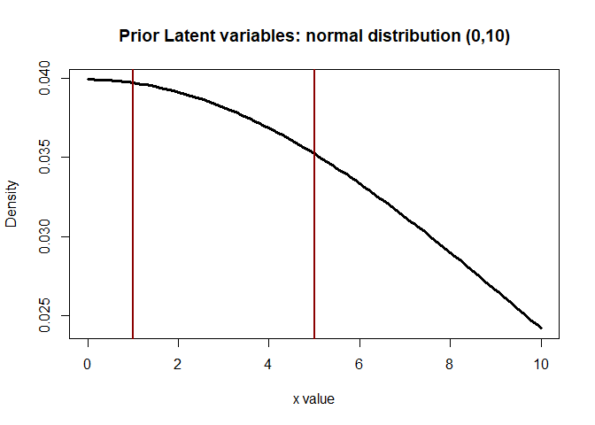

```r
plot(seq(0,10,.1), dnorm(seq(0,10,.1),0,10), type="l", lty=1, lwd = 3, xlab="x value",
     ylab="Density", main="Prior Latent variables: normal distribution (0,10)")
# vertical line
abline(v=1, col="darkred", lwd=2)
abline(v=5, col="darkred", lwd=2)
```

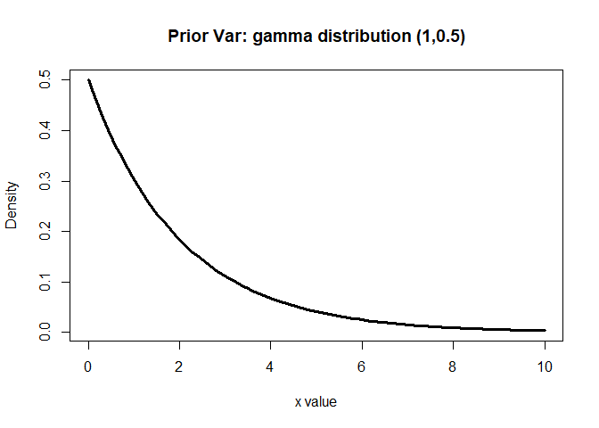

```r
plot(seq(0,10,.1), dgamma(seq(0,10,.1),1,0.5), type="l", lty=1, lwd = 3, xlab="x value",
     ylab="Density", main="Prior Var: gamma distribution (1,0.5)")
```

#### CFA com as variáveis sugeridos pelo artigo

Agora vamos restringir ao conjunto de variáveis que os autores escolheram para cada construto. Usamos o pacote `blavaan` para fazer a modelação bayesiana.

```r
# individual params
n_chains <- 3 # 5
burn_in <- 1500
sample_estimate <- 3000
```

##### Student Ethics

```r
if(correr_single_CFAs_article){
  # Student Ethics
  model.ethics_article <- 'StudentEthics =~ ET12 + ET13'
  fit.ethics_article <- bcfa(model.ethics_article, data = df, std.lv = TRUE,
                        n.chains = n_chains, burnin=burn_in,
                        sample=sample_estimate, target = "stan")
  summary(fit.ethics_article, standardized = TRUE, rsquare = TRUE)
  fitMeasures(fit.ethics_article)
}
```

São apenas 2 variáveis e parecem adequadas para usarmos só estas.

##### Motivation

```r
if(correr_single_CFAs_article){
  # Motivation
  model.motivation_article <- 'Motivation =~ Mot5 + Mot8 + Mot11'
  fit.motivation_article <- bcfa(model.motivation_article, data = df, std.lv = TRUE,
                        n.chains = n_chains, burnin=burn_in,
                        sample=sample_estimate, target = "stan")
  summary(fit.motivation_article, standardized = TRUE, rsquare = TRUE)
  fitMeasures(fit.motivation_article)
}
```

##### Self-Efficacy

```r
if(correr_single_CFAs_article){
  # Self-Efficacy
  model.efficacy_article <- 'SelfEfficacy =~ SE1 + SE2 + SE3 + SE4 + SE5 + SE6'
  fit.efficacy_article <- bcfa(model.efficacy_article, data = df, std.lv = TRUE,
                        n.chains = n_chains, burnin=burn_in,
                        sample=sample_estimate, target = "stan")
  summary(fit.efficacy_article, standardized = TRUE, rsquare = TRUE)
  fitMeasures(fit.efficacy_article)
}
```

São utilizadas todos os itens para o construto, deixaremos assim mesmo.

##### Resilience

```r
if(correr_single_CFAs_article){
  # Resilience
  model.resilience_article <- 'Resilience =~ R2 + R5 + R6'
  fit.resilience_article <- bcfa(model.resilience_article, data = df, std.lv = TRUE,
                        n.chains = n_chains, burnin=burn_in,
                        sample=sample_estimate, target = "stan")
  summary(fit.resilience_article, standardized = TRUE, rsquare = TRUE)
  fitMeasures(fit.resilience_article)
}
```

São utilizadas 3 variáveis para o construto, que são as que têm os loadings mais expressivos quando usadas todos os itens. O R2 parece que tem o loading mais baixo e, por isso, testaremos com R5 e R6 apenas para critério de comparação.

##### Knowledge Articulation

```r
if(correr_single_CFAs_article){
  # Knowledge Articulation
  model.knowledge_article <- 'KnowledgeArticulation =~ KA1 + KA2 + KA3 + KA4 + KA5'
  fit.knowledge_article <- bcfa(model.knowledge_article, data = df, std.lv = TRUE,
                        n.chains = n_chains, burnin=burn_in,
                        sample=sample_estimate, target = "stan")
  summary(fit.knowledge_article, standardized = TRUE, rsquare = TRUE)
  fitMeasures(fit.knowledge_article)
}
```

São utilizadas todos os itens para o construto, deixaremos assim mesmo.

##### Team Strain

```r
if(correr_single_CFAs_article){
  # Team Strain
  model.teamstrain_article <- 'TeamStrain =~ TS10 + TS11 + TS12 + TS13 +
                                     TS14 + TS15 + TS16 + TS17'
  fit.teamstrain_article <- bcfa(model.teamstrain_article, data = df, std.lv = TRUE,
                        n.chains = n_chains, burnin=burn_in,
                        sample=sample_estimate, target = "stan")
  summary(fit.teamstrain_article, standardized = TRUE, rsquare = TRUE)
  fitMeasures(fit.teamstrain_article)
}
```

São utilizados aqueles que têm os loadings mais expressivos e são os que os autores escolheram. Os valores continuam altos e por isso deixamos.

##### Cooperative Classroom Environment

```r
if(correr_single_CFAs_article){
  # Cooperative Classroom Environment
  model.cce_article <- 'CooperativeClassroomEnvironment =~ CCE1 + CCE3 + CCE4 +
                                    CCE5 + CCE8 + CCE9 + CCE10 + CCE11'
  fit.cce_article <- bcfa(model.cce_article, data = df, std.lv = TRUE,
                        n.chains = n_chains, burnin=burn_in,
                        sample=sample_estimate, target = "stan")
  summary(fit.cce_article, standardized = TRUE, rsquare = TRUE)
  fitMeasures(fit.cce_article)
}
```

Este construto parece ter itens mais interessantes para serem testados, então vamos experimentar com os valores mais altos e ver mais detalhadamente para tentar melhorar a análise.

- CCE1: 0.488
- CCE3: 0.421
- CCE4: 0.406
- CCE5: 0.435
- CCE8: 0.422
- CCE9: 0.506
- CCE10: 0.482
- CCE11: 0.499

##### Gráficos

```r
if(correr_single_CFAs_article){
  p1 <- plot_sem_model(fit.ethics_article, "Student Ethics")
  p2 <- plot_sem_model(fit.motivation_article, "Motivation")
  p3 <- plot_sem_model(fit.efficacy_article, "Self Efficacy")
  p4 <- plot_sem_model(fit.resilience_article, "Resilience")
  p5 <- plot_sem_model(fit.knowledge_article, "Knowledge Articulation")
  p6 <- plot_sem_model(fit.teamstrain_article, "Team Strain")
  p7 <- plot_sem_model(fit.cce_article, "Cooperative Classroom Environment")
}
```

#### CFA com variáveis a escolher

Vamos apenas alterar os construtos de “Resilience” e o de “Cooperative Classroom Environment” para ver se conseguimos melhorar os resultados. Serão ajustados os valores e, após isso, comparados com o CFA já realizado.

```r
construct_patterns <- list(
  resilience = "^R[1-6]$",
  cooperative_classroom_environment = "^CCE[1-9]$|^CCE1[0-9]$|^CCE20$"
)

selected_construct_patterns <- list(
  resilience_com_R2 = c("R2", "R5", "R6"),
  resilience_sem_R2 = c("R5", "R6"), # retirar o R2 apesar de ter um valor alto
  cce = c("CCE1", "CCE5", "CCE10", "CCE11", "CCE16", "CCE17", "CCE18", "CCE19")
)

# metrics_results_search1 <- calculate_metrics_all(vars_artigo, construct_patterns)
# metrics_results_search2 <- calculate_metrics_all(vars_artigo, selected_construct_patterns)
```

Para o Resilience vimos que se retirarmos os valores dos loadings ficam melhores e, ao mesmo tempo, o alpha de Cronbach também melhora. Contudo, ficaríamos só com 2 variáveis, o que não é muito interessante porque não tem graus de liberdade (df=0). Vamos testar, mas teremos isto em consideração.

##### Resilience

```r
if(correr_single_CFAs_purpose){
  # Resilience
  model.resilience_purpose <- 'Resilience =~ R5 + R6'
  fit.resilience_purpose <- bcfa(model.resilience_purpose, data = df, std.lv = TRUE,
                        n.chains = n_chains, burnin=burn_in,
                        sample=sample_estimate, target = "stan")
  summary(fit.resilience_purpose, standardized = TRUE, rsquare = TRUE)
  fitMeasures(fit.resilience_purpose)
}
```

```r
if(correr_single_CFAs_purpose){
  blavCompare(fit.resilience_article, fit.resilience_purpose)
}
```

O modelo sem R2 e só com 2 variáveis parece ser melhor.

##### Cooperative Classroom Environment

```r
if(correr_single_CFAs_purpose){
  # Cooperative Classroom Environment
  model.cce_purpose <- 'CooperativeClassroomEnvironment =~ CCE1 + CCE5 + CCE10 + CCE11 +
                                                           CCE16 + CCE17  + CCE18 + CCE19'
  fit.cce_purpose <- bcfa(model.cce_purpose, data = df, std.lv = TRUE,
                        n.chains = n_chains, burnin=burn_in,
                        sample=sample_estimate, target = "stan")
  summary(fit.cce_purpose, standardized = TRUE, rsquare = TRUE)
  fitMeasures(fit.cce_purpose)
}
```

```r
if(correr_single_CFAs_purpose){
  blavCompare(fit.cce_article, fit.cce_purpose)
}
```

O modelo com as variáveis escolhidas parece ser melhor, mas não temos certeza se é mesmo assim e se os itens foram escolhidos pelo seu significado. Isto apenas porque não temos detalhes o que todos os itens indicam, só do CCE1 até ao CCE5.

Vamos sempre comparar as duas abordagens e ver se as nossas variáveis propostas acabam por ser melhores.

### 2 - CFA Global

Vai ter em conta as covariâncias entre os fatores e ver as variâncias.

```r
# individual params
n_chains <- 3 # 5
burn_in <- 500
sample_estimate <- 1500
```

#### Com as variáveis que os autores escolheram

```r
if(correr_multiple_CFA){
  modelcfa.authors <- '
    StudentEthics =~ ET12 + ET13
    Motivation =~ Mot5 + Mot8 + Mot11
    SelfEfficacy =~ SE1 + SE2 + SE3 + SE4 + SE5 + SE6
    Resilience =~ R2 + R5 + R6
    KnowledgeArticulation =~ KA1 + KA2 + KA3 + KA4 + KA5
    TeamStrain =~ TS10 + TS11 + TS12 + TS13 + TS14 + TS15 + TS16 + TS17
    CooperativeClassroomEnvironment =~ CCE1 + CCE3 + CCE4 + CCE5 + CCE8 + CCE9 + CCE10 + CCE11

     # variances
    ET12 ~~ ET12
    ET13 ~~ ET13
    Mot5 ~~ Mot5
    Mot8 ~~ Mot8
    Mot11 ~~ Mot11
    SE1 ~~ SE1
    SE2 ~~ SE2
    SE3 ~~ SE3
    SE4 ~~ SE4
    SE5 ~~ SE5
    SE6 ~~ SE6
    R2 ~~ R2
    R5 ~~ R5
    R6 ~~ R6
    KA1 ~~ KA1
    KA2 ~~ KA2
    KA3 ~~ KA3
    KA4 ~~ KA4
    KA5 ~~ KA5
    TS10 ~~ TS10
    TS11 ~~ TS11
    TS12 ~~ TS12
    TS13 ~~ TS13
    TS14 ~~ TS14
    TS15 ~~ TS15
    TS16 ~~ TS16
    TS17 ~~ TS17
    CCE1 ~~ CCE1
    CCE3 ~~ CCE3
    CCE4 ~~ CCE4
    CCE5 ~~ CCE5
    CCE8 ~~ CCE8
    CCE9 ~~ CCE9
    CCE10 ~~ CCE10
    CCE11 ~~ CCE11
  '
  fitcfa.authors <- bcfa(modelcfa.authors, data = df, std.lv = TRUE,
                        n.chains = n_chains, burnin=burn_in,
                        sample=sample_estimate, target = "stan")
}
```

```r
if(correr_multiple_CFA){
  summary(fitcfa.authors, standardized = TRUE, rsquare = TRUE)
  fitMeasures(fitcfa.authors)
}
```

```r
if(correr_multiple_CFA){
  semPaths(fitcfa.authors,
           what = "std",
           layout = "tree",
           edge.label.cex = 1.0,
           sizeMan = 6,
           sizeLat = 8,
           nCharNodes = 6,
           residuals = TRUE,
           intercepts = FALSE,
           optimizeLatRes = TRUE,
           edge.color = "black",
           color = list(lat = "darkgreen", man = "white"),
           mar = c(6, 6, 6, 6)
  )
}
```

#### Com as variáveis que escolhemos

```r
if(correr_multiple_CFA){
  modelcfa.purpose <- '
    StudentEthics =~ ET12 + ET13
    Motivation =~ Mot5 + Mot8 + Mot11
    SelfEfficacy =~ SE1 + SE2 + SE3 + SE4 + SE5 + SE6
    Resilience =~ R5 + R6
    KnowledgeArticulation =~ KA1 + KA2 + KA3 + KA4 + KA5
    TeamStrain =~ TS10 + TS11 + TS12 + TS13 + TS14 + TS15 + TS16 + TS17
    CooperativeClassroomEnvironment =~ CCE1 + CCE5 + CCE10 + CCE11 + CCE16 + CCE17 + CCE18 + CCE19

     # variances
    ET12 ~~ ET12
    ET13 ~~ ET13
    Mot5 ~~ Mot5
    Mot8 ~~ Mot8
    Mot11 ~~ Mot11
    SE1 ~~ SE1
    SE2 ~~ SE2
    SE3 ~~ SE3
    SE4 ~~ SE4
    SE5 ~~ SE5
    SE6 ~~ SE6
    # R2 ~~ R2
    R5 ~~ R5
    R6 ~~ R6
    KA1 ~~ KA1
    KA2 ~~ KA2
    KA3 ~~ KA3
    KA4 ~~ KA4
    KA5 ~~ KA5
    TS10 ~~ TS10
    TS11 ~~ TS11
    TS12 ~~ TS12
    TS13 ~~ TS13
    TS14 ~~ TS14
    TS15 ~~ TS15
    TS16 ~~ TS16
    TS17 ~~ TS17
    CCE1 ~~ CCE1
    CCE5 ~~ CCE5
    CCE10 ~~ CCE10
    CCE11 ~~ CCE11
    CCE16 ~~ CCE16
    CCE17 ~~ CCE17
    CCE18 ~~ CCE18
    CCE19 ~~ CCE19
  '
  fitcfa.purpose <- bcfa(modelcfa.purpose, data = df, std.lv = TRUE,
                        n.chains = n_chains, burnin=burn_in,
                        sample=sample_estimate, target = "stan")
}
```

```r
if(correr_multiple_CFA){
  summary(fitcfa.purpose, standardized = TRUE, rsquare = TRUE)
  fitMeasures(fitcfa.purpose)
}
```

```r
if(correr_multiple_CFA){
  semPaths(fitcfa.purpose,
           what = "std",
           layout = "tree",
           edge.label.cex = 1.0,
           sizeMan = 6,
           sizeLat = 8,
           nCharNodes = 6,
           residuals = TRUE,
           intercepts = FALSE,
           optimizeLatRes = TRUE,
           edge.color = "black",
           color = list(lat = "darkgreen", man = "white"),
           mar = c(6, 6, 6, 6)
  )
}
```

#### (X) Com todas as variáveis

Demora muito tempo a correr.

```r
if(FALSE){
modelcfa.global <- '
  StudentEthics =~ ET1 + ET2 + ET3 + ET4 + ET5 + ET6 + ET7 + ET8 + ET9 + ET10 + ET11 + ET12 + ET13
  Motivation =~ Mot1 + Mot2 + Mot3 + Mot4 + Mot5 + Mot6 + Mot7 + Mot8 + Mot9 + Mot10 + Mot11 + Mot12 + Mot13 + Mot14 + Mot15
  SelfEfficacy =~ SE1 + SE2 + SE3 + SE4 + SE5 + SE6
  Resilience =~ R1 + R2 + R3 + R4 + R5 + R6
  KnowledgeArticulation =~ KA1 + KA2 + KA3 + KA4 + KA5
  TeamStrain =~ TS1 + TS2 + TS3 + TS4 + TS5 + TS6 + TS7 + TS8 + TS9 + TS10 + TS11 + TS12 + TS13 + TS14 + TS15 + TS16 + TS17
  CooperativeClassroomEnvironment =~ CCE1 + CCE2 + CCE3 + CCE4 + CCE5 + CCE6 + CCE7 + CCE8 + CCE9 + CCE10 + CCE11 + CCE12 + CCE13 + CCE14 + CCE15 + CCE16 + CCE17 + CCE18 + CCE19 + CCE20
'
fitcfa.global <- bcfa(modelcfa.global, data = df, std.lv = TRUE,
                      n.chains = n_chains, burnin=burn_in,
                      sample=sample_estimate, target = "stan")
summary(fitcfa.global, standardized = TRUE, rsquare = TRUE)
fitMeasures(fitcfa.global)

semPaths(fitcfa.global,
         what = "std",
         layout = "tree",
         edge.label.cex = 1.0,
         sizeMan = 6,
         sizeLat = 8,
         nCharNodes = 6,
         residuals = TRUE,
         intercepts = FALSE,
         optimizeLatRes = TRUE,
         edge.color = "black",
         color = list(lat = "darkgreen", man = "white"),
         mar = c(6, 6, 6, 6)
)
}
```

### 3 - SEM

```r
# individual params
n_chains <- 3 # 5
burn_in <- 500
sample_estimate <- 1500
```

#### Estimação com construtos dos autores (dataset original)

Estes itens já foram vistos que serão a média correspondente aos itens escolhidos para os construtos.

```r
# ler csv
df_FAauth <- read.csv("../data/4_conjuntos(dev)/construtos_autores.csv")
df_FAauth
```

| ethics | Motivation | Resilience | SelfEfficacy | TeamStrain | KnowledgeArticulation | CoopClass |
| --- | --- | --- | --- | --- | --- | --- |
| 3.5 | 2.000000 | 4.000000 | 3.666667 | 3.125 | 3.6 | 3.750 |
| 5.0 | 3.000000 | 4.333333 | 4.000000 | 3.625 | 4.2 | 4.000 |
| 1.0 | 1.333333 | 5.000000 | 5.000000 | 4.000 | 4.2 | 4.125 |
| 2.0 | 3.000000 | 3.000000 | 3.000000 | 3.000 | 3.0 | 3.000 |
| 4.0 | 2.333333 | 4.000000 | 3.666667 | 3.625 | 2.8 | 3.875 |
| 3.5 | 2.333333 | 4.000000 | 3.833333 | 4.000 | 3.4 | 3.875 |
| 5.0 | 3.000000 | 4.333333 | 4.000000 | 3.625 | 4.2 | 4.000 |
| 3.5 | 4.000000 | 5.000000 | 4.000000 | 4.000 | 3.8 | 3.625 |
| 3.0 | 2.666667 | 2.666667 | 3.166667 | 3.000 | 4.0 | 3.625 |
| 4.0 | 3.333333 | 5.000000 | 3.666667 | 4.000 | 4.0 | 4.500 |

[output cut: 556 more lines]

```r
if(correr_SEM){
  tic()
  model.sem_FAauthors <- '
    # regressions
    Motivation ~ Resilience + KnowledgeArticulation + TeamStrain + CoopClass
    SelfEfficacy ~ Resilience + KnowledgeArticulation + TeamStrain + CoopClass
    ethics ~ Motivation + SelfEfficacy
  '

  fit.sem_FAauthors <- bcfa(model.sem_FAauthors, data=df_FAauth, std.lv=TRUE, n.chains = n_chains,
                   burnin=burn_in, sample=sample_estimate, target = "stan")
  toc()
}
```

```r
if(correr_SEM){
  summary(fit.sem_FAauthors, standardized=TRUE, rsquare=TRUE)
}
```

```r
if(correr_SEM){
  semPaths(fit.sem_FAauthors,
           what = "std",
           layout = "tree",
           edge.label.cex = 1.0,
           sizeMan = 10,
           sizeLat = 8,
           nCharNodes = 6,
           residuals = TRUE,
           intercepts = FALSE,
           optimizeLatRes = TRUE,
           edge.color = "black",
           color = list(lat = "darkgreen", man = "lightblue"),
           mar = c(6, 6, 6, 6)
  )
}
```

#### Construtos criados por nós

```r
df_FAour <- read.csv("../data/4_conjuntos(dev)/df_OUR_results.csv")
df_FAour
```

| score_factor_Ethics | score_factor_Motivation | score_factor_SelfEfficacy | score_factor_Resilience | score_factor_KnowledgeArticulation | score_factor_TeamStrain | score_factor_CooperativeClassroomEnvironment | mean_factor_Ethics | mean_factor_Motivation | mean_factor_SelfEfficacy | mean_factor_Resilience | mean_factor_KnowledgeArticulation | mean_factor_TeamStrain | mean_factor_CooperativeClassroomEnvironment |
| --- | --- | --- | --- | --- | --- | --- | --- | --- | --- | --- | --- | --- | --- |
| 0.46592249 | -0.88015791 | 0.223235907 | 0.383704704 | -0.56791358 | -1.3950299758 | 0.023821408 | 3.5 | 2.000000 | 3.666667 | 4.000000 | 3.6 | 3.125 | 3.750 |
| 1.88939298 | 0.28459644 | 0.601091394 | 0.546144210 | 0.39751486 | -0.0909414369 | 0.326000264 | 5.0 | 3.000000 | 4.000000 | 4.333333 | 4.2 | 3.625 | 4.000 |
| -2.33893865 | -1.68268592 | 2.395679932 | 1.718439417 | 0.91753265 | 0.3548791289 | 0.640167979 | 1.0 | 1.333333 | 5.000000 | 5.000000 | 4.2 | 4.000 | 4.125 |
| -1.28185574 | 0.32989873 | -1.193497145 | -0.951030009 | -1.64976811 | -1.5063237866 | -1.535693669 | 2.0 | 3.000000 | 3.000000 | 3.000000 | 3.0 | 3.000 | 3.000 |
| 0.83231007 | -0.48515853 | 0.022336715 | 0.383704704 | -1.90431231 | 0.0186187811 | -0.011086472 | 4.0 | 2.333333 | 3.666667 | 4.000000 | 2.8 | 3.625 | 3.875 |
| 0.46592249 | -0.53046083 | 0.416038475 | 0.617848257 | -0.84995703 | 0.3548791289 | 0.178866388 | 3.5 | 2.333333 | 3.833333 | 4.000000 | 3.4 | 4.000 | 3.875 |
| 1.88939298 | 0.28459644 | 0.601091394 | 0.546144210 | 0.39751486 | -0.0909414369 | 0.326000264 | 5.0 | 3.000000 | 4.000000 | 4.333333 | 4.2 | 3.625 | 4.000 |
| 0.14161475 | 1.44935078 | 0.601091394 | 1.718439417 | -0.11157353 | 0.3548791289 | -0.359585631 | 3.5 | 4.000000 | 4.000000 | 5.000000 | 3.8 | 4.000 | 3.625 |
| -0.22477283 | -0.09015916 | -1.000694577 | -1.960885710 | 0.14297066 | -1.5063237866 | -0.718389793 | 3.0 | 2.666667 | 3.166667 | 2.666667 | 4.0 | 3.000 | 3.625 |
| 0.83231007 | 0.69212507 | 0.008136104 | 1.718439417 | 0.14297066 | 0.3548791289 | 1.455887932 | 4.0 | 3.333333 | 3.666667 | 5.000000 | 4.0 | 4.000 | 4.500 |

[output cut: 556 more lines]

##### Média variáveis

Vai ser igual à análise de cima, mas com as médias das variáveis desta vez criada por nós.

```r
if(correr_SEM){
  tic()
  model.sem_meanOUR <- '
    # regressions
    mean_factor_Motivation ~ mean_factor_Resilience + mean_factor_KnowledgeArticulation + mean_factor_TeamStrain + mean_factor_CooperativeClassroomEnvironment
    mean_factor_SelfEfficacy ~ mean_factor_Resilience + mean_factor_KnowledgeArticulation + mean_factor_TeamStrain + mean_factor_CooperativeClassroomEnvironment
    mean_factor_Ethics ~ mean_factor_Motivation + mean_factor_SelfEfficacy
  '

  fit.sem_meanOUR <- bcfa(model.sem_meanOUR, data=df_FAour, std.lv=TRUE, n.chains = n_chains,
                   burnin=burn_in, sample=sample_estimate, target = "stan")
  toc()
}
```

```r
if(correr_SEM){
  summary(fit.sem_meanOUR, standardized=TRUE, rsquare=TRUE)
}
```

```r
if(correr_SEM){
  semPaths(fit.sem_meanOUR,
           what = "std",
           layout = "tree",
           edge.label.cex = 1.0,
           sizeMan = 10,
           sizeLat = 8,
           nCharNodes = 6,
           residuals = TRUE,
           intercepts = FALSE,
           optimizeLatRes = TRUE,
           edge.color = "black",
           color = list(lat = "darkgreen", man = "lightblue"),
           mar = c(6, 6, 6, 6)
  )
}
```

Conseguimos replicar na perfeição os valores do artigo.

##### CFA

```r
if(correr_SEM){
  tic()
  model.sem_CFAOUR <- '
    # regressions
    score_factor_Motivation ~ score_factor_Resilience + score_factor_KnowledgeArticulation + score_factor_TeamStrain + score_factor_CooperativeClassroomEnvironment
    score_factor_SelfEfficacy ~ score_factor_Resilience + score_factor_KnowledgeArticulation + score_factor_TeamStrain + score_factor_CooperativeClassroomEnvironment
    score_factor_Ethics ~ score_factor_Motivation + score_factor_SelfEfficacy
  '

  fit.sem_CFAOUR <- bcfa(model.sem_CFAOUR, data=df_FAour, std.lv=TRUE, n.chains = n_chains,
                   burnin=burn_in, sample=sample_estimate, target = "stan")
  toc()
}
```

```r
if(correr_SEM){
  summary(fit.sem_CFAOUR, standardized=TRUE, rsquare=TRUE)
}
```

```r
if(correr_SEM){
  semPaths(fit.sem_CFAOUR,
           what = "std",
           layout = "tree",
           edge.label.cex = 1.0,
           sizeMan = 10,
           sizeLat = 8,
           nCharNodes = 6,
           residuals = TRUE,
           intercepts = FALSE,
           optimizeLatRes = TRUE,
           edge.color = "black",
           color = list(lat = "darkgreen", man = "lightblue"),
           mar = c(6, 6, 6, 6)
  )
}
```

#### Estimação seguida com FA criadas no próprio modelo

Agora faremos uma abordagem full SEM que consiste em fazer a modelação de todos os construtos e depois fazer a modelação SEM. Vamos replicar na exatidão o que é proposto no artigo mas tudo seguido e não CFA seguido de SEM.

```r
if(correr_SEM){
  tic()
  model.sem <- '
    # measurement model
    StudentEthics =~ ET12 + ET13
    Motivation =~ Mot5 + Mot8 + Mot11
    SelfEfficacy =~ SE1 + SE2 + SE3 + SE4 + SE5 + SE6
    Resilience =~ R2 + R5 + R6
    KnowledgeArticulation =~ KA1 + KA2 + KA3 + KA4 + KA5
    TeamStrain =~ TS10 + TS11 + TS12 + TS13 + TS14 + TS15 + TS16 + TS17
    CooperativeClassroomEnvironment =~ CCE1 + CCE3 + CCE4 + CCE5 + CCE8 + CCE9 + CCE10 + CCE11

    # regressions
    Motivation ~ Resilience + KnowledgeArticulation + TeamStrain + CooperativeClassroomEnvironment
    SelfEfficacy ~ Resilience + KnowledgeArticulation + TeamStrain + CooperativeClassroomEnvironment
    StudentEthics ~ Motivation + SelfEfficacy

  '

  fit.sem <- bcfa(model.sem, data=df, std.lv=TRUE, n.chains = n_chains,
                   burnin=burn_in, sample=sample_estimate, target = "stan")
  toc()
}
```

```r
if(correr_SEM){
  summary(fit.sem, standardized=TRUE, rsquare=TRUE)
}
```

```r
if(correr_SEM){
  inspect(fit.sem, what = "std")$lambda
}
```

```r
if(correr_SEM){
  semPaths(fit.sem,
           what = "std",
           layout = "tree",
           edge.label.cex = 0.4,
           sizeMan = 3,
           sizeLat = 8,
           nCharNodes = 6,
           residuals = TRUE,
           intercepts = FALSE,
           optimizeLatRes = TRUE,
           edge.color = "black",
           color = list(lat = "darkgreen", man = "white"),
           mar = c(6, 6, 6, 6)
  )
}
```

```r
if (correr_SEM) {
  mcs_SEM <- blavInspect(fit.sem, "mcmc")
  mcs_SEM <- as.matrix(mcs_SEM)

  analisar_coluna <- function(col_data, nome_coluna) {
    col_data <- as.numeric(col_data)
    col_data <- col_data[!is.na(col_data)]

    if (length(unique(col_data)) < 2) {
      return(NULL)
    }

    p <- quantile(col_data, probs = c(0.05, 0.25, 0.5, 0.75, 0.95), na.rm = TRUE)
    media <- mean(col_data)
    sd_val <- sd(col_data)

    fit_norm <- fitdist(col_data, "norm")
    fit_lognorm <- tryCatch(fitdist(col_data, "lnorm"), error = function(e) NULL)
    fit_gamma <- tryCatch(fitdist(col_data, "gamma"), error = function(e) NULL)
    fit_exp <- tryCatch(fitdist(col_data, "exp"), error = function(e) NULL)

    fits <- list(norm = fit_norm, lnorm = fit_lognorm, gamma = fit_gamma, exp = fit_exp)
    aic_vals <- sapply(fits, function(f) if (!is.null(f)) f$aic else Inf)
    best_dist <- names(which.min(aic_vals))

    data.frame(
      variavel = nome_coluna,
      p5 = p[1],
      p25 = p[2],
      p50 = p[3],
      p75 = p[4],
      p95 = p[5],
      media = media,
      sd = sd_val,
      melhor_distribuicao = best_dist,
      stringsAsFactors = FALSE
    )
  }

  resultados <- lapply(seq_len(ncol(mcs_SEM)), function(i) {
    analisar_coluna(mcs_SEM[, i], colnames(mcs_SEM)[i])
  })

  resumo_mcs <- do.call(rbind, Filter(Negate(is.null), resultados))
}
```

```r
if (correr_SEM) {
  dim(mcs_SEM)
  # colnames(mcs_SEM)

  # mean(mcs_SEM[,1])
  # sd(mcs_SEM[,1])

  hist(mcs_SEM[,1]) # dist normal
  hist(mcs_SEM[,4]) # tem dist gamma?

  sum(mcs_SEM[,1] > .74)/nrow(mcs_SEM) # [1] 0.9995556
}
```

```r
if (correr_SEM) {
  resumo_mcs
}
```

```r
if (correr_SEM) {
  ML_SEM_bs <- blavFitIndices(fit.sem)
  summary(ML_SEM_bs, prob=.95,central.tendency = c("mean","median"))
}
```

```r
if (correr_SEM) {
  distML_SEM <- data.frame(ML_SEM_bs@indices)
  sum(distML_SEM$BGammaHat > .88)/nrow(distML_SEM) # maior que .88
  hist(distML_SEM$BGammaHat)
}
```

```r
if (correr_SEM) {
  mcmc_pairs(distML_SEM, pars = c("BRMSEA","BGammaHat","adjBGammaHat"), diag_fun =
  "hist")
}
```

#### Tentativa de melhoria com o SEM seguido

```r
if(correr_SEM){
  tic()
  model.sem_fullpurpose <- '
    # measurement model
    StudentEthics =~ ET12 + ET13
    Motivation =~ Mot5 + Mot8 + Mot11
    SelfEfficacy =~ SE1 + SE2 + SE3 + SE4 + SE5 + SE6
    Resilience =~ R5 + R6
    KnowledgeArticulation =~ KA1 + KA2 + KA3 + KA4 + KA5
    TeamStrain =~ TS10 + TS11 + TS12 + TS13 + TS14 + TS15 + TS16 + TS17
    CooperativeClassroomEnvironment =~ CCE1 + CCE5 + CCE10 + CCE11 + CCE16 + CCE17 + CCE18 + CCE19

    # regressions
    Motivation ~ Resilience + KnowledgeArticulation + TeamStrain + CooperativeClassroomEnvironment
    SelfEfficacy ~ Resilience + KnowledgeArticulation + TeamStrain + CooperativeClassroomEnvironment
    StudentEthics ~ Motivation + SelfEfficacy

  '

  fit.sem_fullpurpose <- bcfa(model.sem_fullpurpose, data=df, std.lv=TRUE, n.chains = n_chains,
                   burnin=burn_in, sample=sample_estimate, target = "stan")
  toc()
}
```

```r
if(correr_SEM){
  summary(fit.sem_fullpurpose, standardized=TRUE, rsquare=TRUE)
}
```

```r
if(correr_SEM){
  inspect(fit.sem_fullpurpose, what = "std")$lambda
}
```

```r
if(correr_SEM){
  semPaths(fit.sem_fullpurpose,
           what = "std",
           layout = "tree",
           edge.label.cex = 0.4,
           sizeMan = 3,
           sizeLat = 8,
           nCharNodes = 6,
           residuals = TRUE,
           intercepts = FALSE,
           optimizeLatRes = TRUE,
           edge.color = "black",
           color = list(lat = "darkgreen", man = "white"),
           mar = c(6, 6, 6, 6)
  )
}
```

#### Comparação entre os dois SEM

```r
if(correr_SEM){
  blavCompare(fit.sem_FAauthors, fit.sem_meanOUR)
  # blavCompare(fit.sem, fit.sem_FAauthors) # não comparável
  # blavCompare(fit.sem_fullpurpose, fit.sem_FAauthors) # não comparável
  blavCompare(fit.sem, fit.sem_fullpurpose)
}
```

### 4- SEM com priors

#### Priors para lambda, beta e ET12 e ET13

Estudo de algumas priors baseado nos valores de loadings obtidos e os do paper. Veremos algumas distribuições conhecidas e tentar adaptar o valor do lambda para uma normal porque a função `dpriors` tem limitações em quais priors pode replicar.

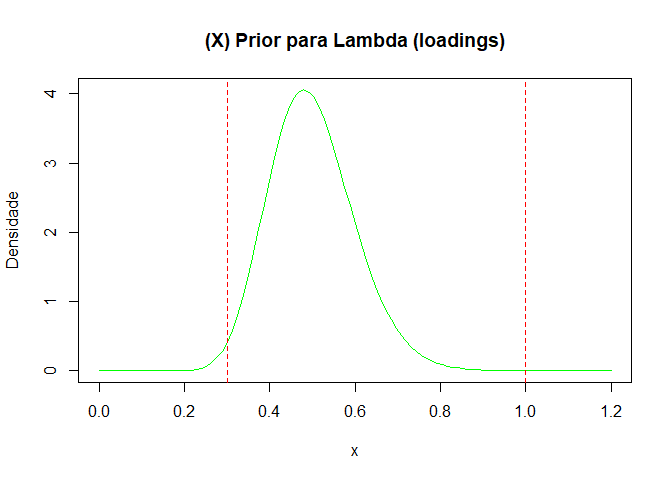

```r
curve(dgamma(x, 25, 50), from=0, to=1.2, main="(X) Prior para Lambda (loadings)", col = "green", ylab="Densidade")
abline(v=c(0.3, 1), col="red", lty=2)
```

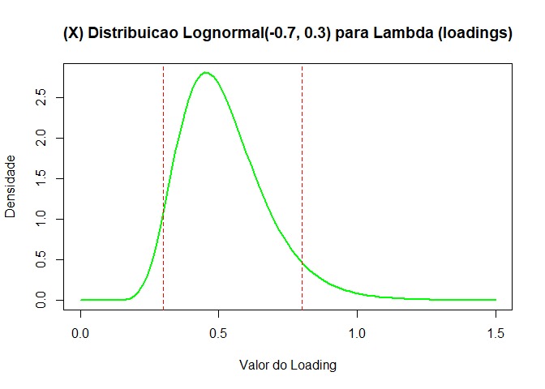

```r
curve(dlnorm(x, meanlog = -0.7, sdlog = 0.3),
      from = 0, to = 1.5,
      col = "green", lwd = 2,
      ylab = "Densidade", xlab = "Valor do Loading",
      main = "(X) Distribuicao Lognormal(-0.7, 0.3) para Lambda (loadings)")
abline(v = c(0.3, 0.8), col = "red", lty = 2)
```

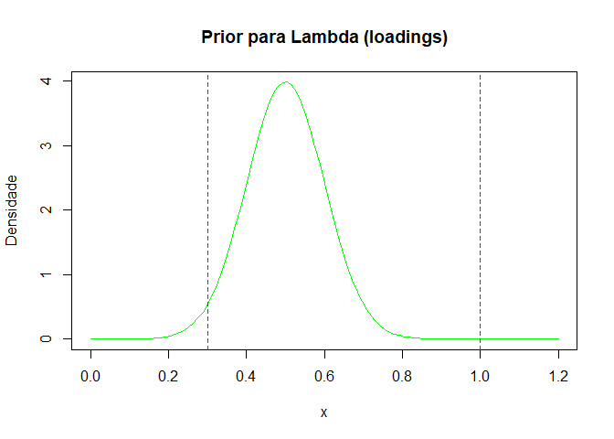

```r
curve(dnorm(x, 0.5, 0.1), from=0, to=1.2, main="Prior para Lambda (loadings)", col = "green", ylab="Densidade")
abline(v=c(0.3, 1), col="red", lty=2)
```

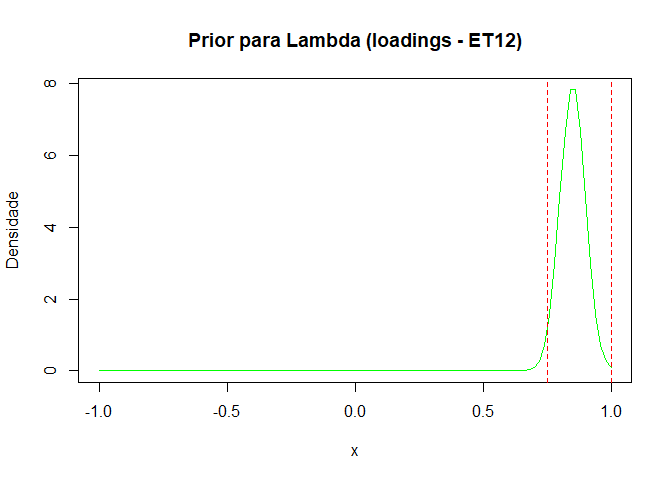

```r
curve(c(dnorm(x, 0.85, 0.05)), from=-1, to=1, col = "green", main="Prior para Lambda (loadings - ET12)", ylab="Densidade")
abline(v=c(0.75, 1.0), col="red", lty=2)
```

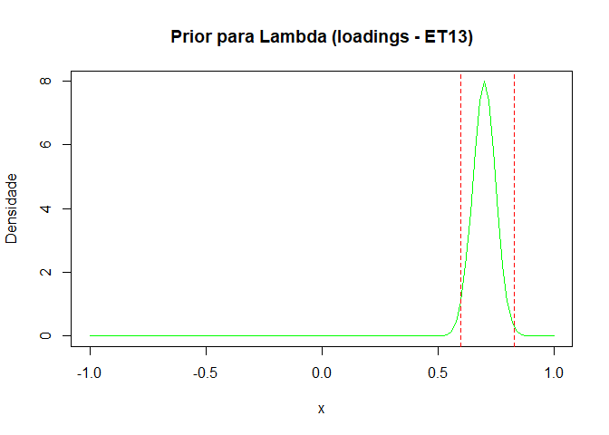

```r
curve(c(dnorm(x, 0.7, 0.05)), from=-1, to=1, col = "green", main="Prior para Lambda (loadings - ET13)", ylab="Densidade")
abline(v=c(0.6, 0.83), col="red", lty=2)
```

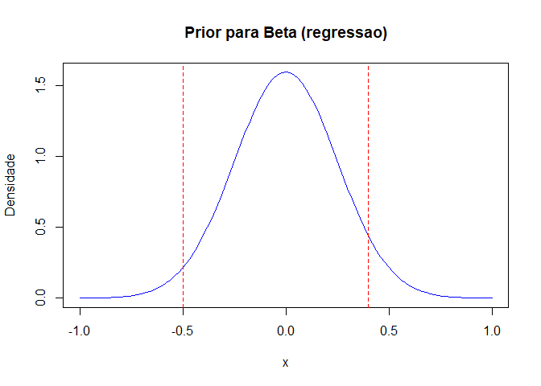

```r
curve(dnorm(x, 0, 0.25), from=-1, to=1,col = "blue", main="Prior para Beta (regressao)", ylab="Densidade")
abline(v=c(-0.5, 0.4), col="red", lty=2)
```

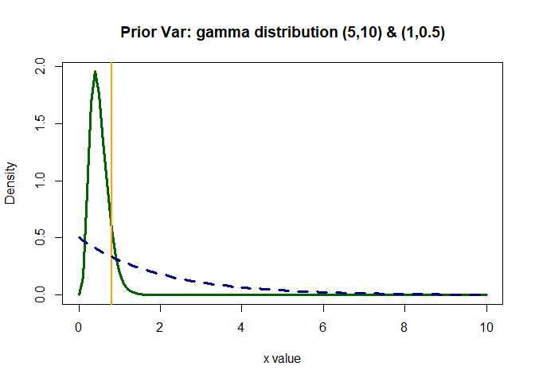

```r
plot(seq(0,10,.1), dgamma(seq(0,10,.1),5, 10), type="l", lty=1, lwd = 3, xlab="x value",
     ylab="Density", main="Prior Var: gamma distribution (5,10) & (1,0.5)", col = "darkgreen")
abline(v=.8, col="orange", lwd=2)
lines(seq(0,10,.1), dgamma(seq(0,10,.1),1,0.5), col = "darkblue", lwd = 3, lty = 2)
```

```r
# individual params
n_chains <- 3 # 3
burn_in <- 500 # 200
sample_estimate <- 1500 #1000
```

```r
if(correr_SEM_cpriors){
  tic()
  dp <- dpriors(lambda = "normal(0.5, 0.1)", # semelhante "gamma(25, 50)"; nao conchigo utilizar gamma :(
                beta   = "normal(0, 0.25)" # talvez aumentar um pouco mais sd (cauda mais longa)
                #, theta  = "gamma(5, 10)" # variances
                )
  model.sem_priors <- '
    # measurement model
    StudentEthics =~ prior("normal(0.85, 0.05)")*ET12 + prior("normal(0.7, 0.05)")*ET13
    Motivation =~ Mot5 + Mot8 + Mot11
    SelfEfficacy =~ SE1 + SE2 + SE3 + SE4 + SE5 + SE6
    Resilience =~ R2 + R5 + R6
    KnowledgeArticulation =~ KA1 + KA2 + KA3 + KA4 + KA5
    TeamStrain =~ TS10 + TS11 + TS12 + TS13 + TS14 + TS15 + TS16 + TS17
    CooperativeClassroomEnvironment =~ CCE1 + CCE3 + CCE4 + CCE5 + CCE8 + CCE9 + CCE10 + CCE11

    # regressions
    Motivation ~ Resilience + KnowledgeArticulation + TeamStrain + CooperativeClassroomEnvironment
    SelfEfficacy ~ Resilience + KnowledgeArticulation + TeamStrain + CooperativeClassroomEnvironment
    StudentEthics ~ Motivation + SelfEfficacy

  '

  fit.sem_priors <- bcfa(model.sem_priors, data=df, std.lv=TRUE, n.chains = n_chains,
                   burnin=burn_in, sample=sample_estimate, target = "stan", dp = dp)
  toc()
}
```

```r
if(correr_SEM_cpriors){
  summary(fit.sem_priors, standardized=TRUE, rsquare=TRUE)
}
```

```r
if(correr_SEM_cpriors){
  semPaths(fit.sem_priors,
           what = "std",
           layout = "tree",
           edge.label.cex = 1.0,
           sizeMan = 10,
           sizeLat = 8,
           nCharNodes = 6,
           residuals = TRUE,
           intercepts = FALSE,
           optimizeLatRes = TRUE,
           edge.color = "black",
           color = list(lat = "darkgreen", man = "lightblue"),
           mar = c(6, 6, 6, 6)
  )
}
```

```r
if(correr_SEM_cpriors){
  blavCompare(fit.sem_priors, fit.sem)
  (fits_SEModels <- cbind(fitMeasures(fit.sem_priors), fitMeasures(fit.sem)))
}
```

#### Priors com regressão 0

```r
if(correr_SEM_cpriors){
  tic()
  dp <- dpriors(lambda = "normal(0.5, 0.1)", # semelhante "gamma(25, 50)"; nao conchigo utilizar gamma :(
                beta   = "normal(0, 0.25)" # talvez aumentar um pouco mais sd (cauda mais longa)
                #, theta  = "gamma(5, 10)" # variances
                )
  model.sem_priors_reg0 <- '
    # measurement model
    StudentEthics =~ prior("normal(0.85, 0.05)")*ET12 + prior("normal(0.7, 0.05)")*ET13
    Motivation =~ Mot5 + Mot8 + Mot11
    SelfEfficacy =~ SE1 + SE2 + SE3 + SE4 + SE5 + SE6
    Resilience =~ R2 + R5 + R6
    KnowledgeArticulation =~ KA1 + KA2 + KA3 + KA4 + KA5
    TeamStrain =~ TS10 + TS11 + TS12 + TS13 + TS14 + TS15 + TS16 + TS17
    CooperativeClassroomEnvironment =~ CCE1 + CCE3 + CCE4 + CCE5 + CCE8 + CCE9 + CCE10 + CCE11

    # regressions
    Motivation ~ Resilience + KnowledgeArticulation + TeamStrain + CooperativeClassroomEnvironment
    SelfEfficacy ~ Resilience + KnowledgeArticulation + TeamStrain + prior("normal(0, 0.0001)")*CooperativeClassroomEnvironment
    StudentEthics ~ Motivation + SelfEfficacy

  '

  fit.sem_priors_reg0 <- bcfa(model.sem_priors_reg0, data=df, std.lv=TRUE, n.chains = n_chains,
                   burnin=burn_in, sample=sample_estimate, target = "stan", dp = dp)
  toc()
}
```

```r
if(correr_SEM_cpriors){
  summary(fit.sem_priors_reg0, standardized=TRUE, rsquare=TRUE)
}
```

```r
if(correr_SEM_cpriors){
  semPaths(fit.sem_priors_reg0,
           what = "std",
           layout = "tree",
           edge.label.cex = 1.0,
           sizeMan = 10,
           sizeLat = 8,
           nCharNodes = 6,
           residuals = TRUE,
           intercepts = FALSE,
           optimizeLatRes = TRUE,
           edge.color = "black",
           color = list(lat = "darkgreen", man = "lightblue"),
           mar = c(6, 6, 6, 6)
  )
}
```

```r
if(correr_SEM_cpriors){
  blavCompare(fit.sem_priors, fit.sem_priors_reg0)
  (fits_SEModels <- cbind(fitMeasures(fit.sem_priors), fitMeasures(fit.sem_priors_reg0)))
}
```